# Self Reports

Awais Farooq

4/30/2020

```
## [1] 120000
```

**Patient self-reports are a method in which investigators can gather health related information from a Patient’s perspective in regards to their perceived health care status and pertinent social determinants of health. Patient self-reports can provide vital insights in the quality and trends of care a patient receives. With this paradigm established we can begin to describe the scope and approach of this analysis. Patient self reports in the military health care system allow for the aggregation and analysis of a wide variety of patient symptoms. In patients diagnosed with TBI, a plethora of comorbid neuropsychiatric issues can arrise. An extensive amount of patient self reported from three data sources shall be compiled in this analyss and analyzed.**

**The Behavioral Health Data Portal (BHDP) misson statement can be summarized as; Improving behavioral health clincal care and risk tracking via standardized data collection disseminated in real time for provioder viewership, supporting evidence based practices and outcomes data for clinical practice, and simplication of data sources via integration of relavent data sources across the Army Medical department. Multiple standardized survey assements were administered to Service Memebers(SMs) in this analyis from March 10th 2009 to August 6th 2019. In total 13 total Survey types have been gathered from various data sources. Data pulls occured from the BHDP dataset which contains almost 747,000 observations, BAMC which contains 5143 observations and NICOE which contained 8562 observations. For the purposes of this analysis, the Neurobehavioral Symptom Inventory (NSI) will be utilized a primary measure of correspondance to other Self reported assessments.**

**Certain considerations are to be made when analyzing survey data. Cut scores are applied to all data to filter surveys that deemed to be clinically inacurate. An example of this would be filtering out surveys with a NSI Validity 10 score of 22 or more.**

## Surveys

### NSI Counts

**Given that our key parameter in this analysis is how various Surveys correlate against NSI, our first analysis begins with counting the number of possible NSI surveys from our three data sources. A key point to highlight here is the nature of the data being derived from each source. BHDP and NICOE provide individual question answers for the vast majority of their surveys. BAMC provides only total scores from surveys and one field of 22 question from the actual NSI survey. The counts for NSI total score are filtered by “cut” scores. This same approach is applied to all surveys tabulated in this analysis hence forth.**

NSI Survey counts

| data_source | bamc | bhdp | nicoe | Total |
| --- | --- | --- | --- | --- |
| NSI_TotalScore | 4894 | 4914 | 6707 | 16515 |
| NSI_Validity_10 | 4612 | 4441 | 5966 | 15019 |
| NSI_F4_Sensory | 4893 | 4914 | 6707 | 16514 |
| NSI_F3_Affective | 4890 | 4913 | 6707 | 16510 |
| NSI_F2_Cognative | 4890 | 4914 | 6707 | 16511 |
| NSI_F1_Vestibular | 4894 | 4913 | 6707 | 16514 |
| NSI.Headaches_V1 | 4893 | 4914 | 6707 | 16514 |
| NSI.Anxious_V1 | 0 | 4901 | 6707 | 11608 |
| NSI.Appetite_Change_V1 | 0 | 4886 | 6707 | 11593 |
| NSI.Balance_V1 | 0 | 4907 | 6707 | 11614 |
| NSI.Clumsy_V1 | 0 | 4910 | 6707 | 11617 |
| NSI.Decision_Difficulty_V1 | 0 | 4882 | 6707 | 11589 |
| NSI.Depressed_V1 | 0 | 4827 | 6707 | 11534 |
| NSI.Distracted_V1 | 0 | 4913 | 6707 | 11620 |
| NSI.Dizzy_V1 | 0 | 4912 | 6707 | 11619 |
| NSI.Fatigue_V1 | 0 | 4912 | 6707 | 11619 |
| NSI.Forgetfulness_V1 | 0 | 4913 | 6707 | 11620 |
| NSI.Hearing_Difficulty | 0 | 4912 | 6707 | 11619 |
| NSI.Irritability_V1 | 0 | 4908 | 6707 | 11615 |
| NSI.Light_Sensitivity_V1 | 0 | 4912 | 6707 | 11619 |
| NSI.Nausea_V1 | 0 | 4913 | 6707 | 11620 |
| NSI.Noise_Sensitivity_V1 | 0 | 4913 | 6707 | 11620 |
| NSI.Numbness_V1 | 0 | 4914 | 6707 | 11621 |
| NSI.Overwhelmed_V1 | 0 | 4908 | 6707 | 11615 |
| NSI.Sleep_Difficulty_V1 | 0 | 4909 | 6707 | 11616 |
| NSI.Slow_Thinking_V1 | 0 | 4912 | 6707 | 11619 |
| NSI.Taste_Smell_Change_V1 | 0 | 4909 | 6707 | 11616 |
| NSI.Vision_Problems_V1 | 0 | 4913 | 6707 | 11620 |

**The table below illustrates the break down of how many question were answered for each NSI question. The majority of question answered are 22, with over 11,000 surveys shown to be completed. The numbers taper down until they reach “1”. The reason about 4900 surveys have only “one” question answered here is because from BAMC, an exact amount of answeres are given for the field regarding NSI Headaches. The total score for BAMC may still be derived from other question columns not provided in this dataset. “0” question answered here occurs when there is a total score from a database, but no corresponding columns of questions totaling that total score. In this case there is one instance of this. This only shows up for certain Survey Questions is usually due to BAMC not having the same level of detail as other data sources.**

NSI Survey Question counts

| NSI_Questions_Complete | count |
| --- | --- |
| 0 | 0.01% (1) |
| 1 | 29.63% (4893) |
| 13 | 0.01% (1) |
| 17 | 0.01% (1) |
| 18 | 0.01% (1) |
| 19 | 0.04% (6) |
| 20 | 0.01% (2) |
| 21 | 1.02% (168) |
| 22 | 69.28% (11442) |
| Total | 100.00% (16515) |

### HIT6 Counts

**Below we have similar counts of HIT6 sources and the amount of questions answered from each individual source. These HIT6 scores are ones that have a corresponding NSI the day of the test. NICOE has the majority of HIT6 scores as the table demonstrates. There is an additonal field in the BHDP data source labled “experiences headaches” which does not exist in the NICOE database and was not found to be part of the official HIT6 quesionnaire, therefore it was not utilized in tabulating total scores.**

HIT6 Survey counts

| data_source | bamc | bhdp | nicoe | Total |
| --- | --- | --- | --- | --- |
| HIT6_Score | 712 | 1547 | 6073 | 8332 |
| HIT.Irritated_V1 | 0 | 1548 | 6073 | 7621 |
| HIT.Limit_Activities_V1 | 0 | 1546 | 6072 | 7618 |
| HIT.Pain_Severity_V1 | 0 | 1549 | 6073 | 7622 |
| HIT.Too_Tired_V1 | 0 | 1548 | 6073 | 7621 |
| HIT.Trouble_Concentrate_V1 | 0 | 1548 | 6073 | 7621 |
| HIT.Wish_to_Lie_Down_V1 | 0 | 1546 | 6073 | 7619 |
| HIT.Experience_Headaches_V1 | 0 | 1718 | 0 | 1718 |

**We can see in the table below the majority of survey answered are almost fully complete, with approximately 91% of surveys completed. 712 “Zero” questions answered is due again to BAMC not having any individual fields to show how many of their individual questions have been answered**

HIT6 Survey Question counts

| HIT6_Questions_Complete | count |
| --- | --- |
| 0 | 8.55% (712) |
| 5 | 0.05% (4) |
| 6 | 91.41% (7616) |
| Total | 100.00% (8332) |

### pHQ9

**In this table we see a total of approximately 7600 PHQ9 scores coming from two data sources, NICOE and BHDP. BAMC has no total scores to contribute so we expect no “0” answers in the question count analysis**

PHQ9 Survey counts

| data_source | bamc | bhdp | nicoe | Total |
| --- | --- | --- | --- | --- |
| PHQ9_Score | 0 | 3087 | 4541 | 7628 |
| PHQ9.APPETITE_V1 | 0 | 1468 | 4539 | 6007 |
| PHQ9.DEPRESSED_V1 | 0 | 3086 | 4539 | 7625 |
| PHQ9.FEEL_BAD_V1 | 0 | 1467 | 4530 | 5997 |
| PHQ9.FEEL_TIRED_V1 | 0 | 1468 | 4534 | 6002 |
| PHQ9.MOVE_SLOWLY_V1 | 0 | 1467 | 4534 | 6001 |
| PHQ9.NO_INTEREST_V1 | 0 | 3086 | 4540 | 7626 |
| PHQ9.TROUBLE_CONCENTRATING_V1 | 0 | 1468 | 4534 | 6002 |
| PHQ9.TROUBLE_SLEEPING_V1 | 0 | 1468 | 4539 | 6007 |
| PHQ9.Q9_V1 | 0 | 1460 | 4530 | 5990 |

**Encourgagingly we see that the vast majority of surveys have been completed in PHQ9. The second highest total is however for “2” with about 1600 surveys only having 2 fields filled..**

PHQ9 Survey Question counts Subsetted in Corresponding NSI

| PHQ9_Questions_Complete | count |
| --- | --- |
| 2 | 21.22% (1619) |
| 7 | 0.04% (3) |
| 8 | 0.73% (56) |
| 9 | 78.00% (5950) |
| Total | 100.00% (7628) |

### pHQ8

**In this table we see a total of approximately 1337 PHQ8 scores coming from only the NICOE.**

PHQ8 Survey counts

| data_source | bamc | bhdp | nicoe | Total |
| --- | --- | --- | --- | --- |
| phq8_tot_score | 0 | 0 | 1337 | 1337 |
| phq8_q1 | 0 | 0 | 1337 | 1337 |
| phq8_q2 | 0 | 0 | 1337 | 1337 |
| phq8_q3 | 0 | 0 | 1337 | 1337 |
| phq8_q4 | 0 | 0 | 1337 | 1337 |
| phq8_q5 | 0 | 0 | 1337 | 1337 |
| phq8_q6 | 0 | 0 | 1337 | 1337 |
| phq8_q7 | 0 | 0 | 1337 | 1337 |
| phq8_q8 | 0 | 0 | 1337 | 1337 |

**Encourgagingly we see that all of the PHQ8 questions have been completed.**

PHQ8 Survey Question counts Subsetted in Corresponding NSI

| PHQ8_Questions_Complete | count |
| --- | --- |
| 8 | 100.00% (1337) |
| Total | 100.00% (1337) |

### GAD7

**GAD7 similarly to PHQ9 derives all of its surveys from BHDP and NICOE. The discrepency in the total amount of GAD Total scores to indiviual questions stems from the fact a cut score is applied to GAD Total scores thus lowering the total amount. 5302 GAD total scores are valid the majority coming from NICOE as a data source.**

GAD7 Survey counts

| data_source | bamc | bhdp | nicoe | Total |
| --- | --- | --- | --- | --- |
| GAD_Score | 0 | 2299 | 3003 | 5302 |
| GAD.2.Q1_V1 | 0 | 3197 | 4897 | 8094 |
| GAD.2.Q2_V1 | 0 | 3194 | 4897 | 8091 |
| GAD.7.Q3_V1 | 0 | 1523 | 4897 | 6420 |
| GAD.7.Q4_V1 | 0 | 1523 | 4897 | 6420 |
| GAD.7.Q5_V1 | 0 | 1522 | 4897 | 6419 |
| GAD.7.Q6_V1 | 0 | 1522 | 4897 | 6419 |
| GAD.7.Q7_V1 | 0 | 1521 | 4897 | 6418 |

**In this table we see that almost 70% of GAD7 surveys end up being completed. The second highest number comes from 2 questions completed. This could be postulated from the fact GAD also has a two item screener and those SM who answered only 2 questions did not warrant completion of an entire survey**

GAD7 Survey Question counts Subsetted in Corresponding NSI

| GAD7_Questions_Complete | count |
| --- | --- |
| 1 | 0.04% (2) |
| 2 | 31.54% (1672) |
| 4 | 0.02% (1) |
| 7 | 68.41% (3627) |
| Total | 100.00% (5302) |

### ISI

**ISI is only derived from BHDP in this analysis. Interestingly the total amount of individual scores do not exceed the amount of valid total scores**

ISI Survey counts

| data_source | bamc | bhdp | nicoe | Total |
| --- | --- | --- | --- | --- |
| ISI_Score | 0 | 4360 | 0 | 4360 |
| ISI.Screen.TROUBLE_SLEEPING_V1 | 0 | 3719 | 0 | 3719 |
| ISI.Awakening_Early_V1 | 0 | 2852 | 0 | 2852 |
| ISI.Difficulty_Staying_Asleep_V1 | 0 | 2850 | 0 | 2850 |
| ISI.Noticable_To_Others_V1 | 0 | 2844 | 0 | 2844 |
| ISI.Sleep_Pattern_Satisfaction_V1 | 0 | 2853 | 0 | 2853 |
| ISI.Sleep_Problem_Interferes_V1 | 0 | 2846 | 0 | 2846 |
| ISI.Sleep_Problem_Worried_V1 | 0 | 2851 | 0 | 2851 |

ISI Survey counts

| ISI_Questions_Complete | count |
| --- | --- |
| 1 | 34.56% (1507) |
| 5 | 0.11% (5) |
| 6 | 14.98% (653) |
| 7 | 50.34% (2195) |
| Total | 100.00% (4360) |

### AUDIT

**Audit in this analysis once again is derived from BHDP. AUDIT in our total score analysis is composed of AUDIT C and the subsequent audit questions. More Audit C questions are answered then the subsequent 7 questions that follow. Interestingly, the amount of audit C questions has notable variability.**

AUDIT Survey counts

| data_source | bamc | bhdp | nicoe | Total |
| --- | --- | --- | --- | --- |
| AUDIT_Score | 0 | 2465 | 0 | 2465 |
| AUDIT.C.HOW_MANY_DRINKS_V1 | 0 | 1787 | 0 | 1787 |
| AUDIT.C.HOW_OFTEN_DRINK_V1 | 0 | 2465 | 0 | 2465 |
| AUDIT.C.SIX_OR_MORE_DRINK_V1 | 0 | 1814 | 0 | 1814 |
| AUDIT.Q10_V1 | 0 | 903 | 0 | 903 |
| AUDIT.Q4_V1 | 0 | 903 | 0 | 903 |
| AUDIT.Q5_V1 | 0 | 817 | 0 | 817 |
| AUDIT.Q6_V1 | 0 | 786 | 0 | 786 |
| AUDIT.Q7_V1 | 0 | 904 | 0 | 904 |
| AUDIT.Q8_V1 | 0 | 902 | 0 | 902 |
| AUDIT.Q9_V1 | 0 | 818 | 0 | 818 |

**More so then other surveys so far, there is much more variability in the question count distribution in AUDIT. Three questions answered then any other amount. About 27% of surveys were completed and 26% only had one field filled out. Considerations can be made to filter our surveys with only 1 question answered**

AUDIT Survey counts

| AUDIT_Questions_Complete | count |
| --- | --- |
| 1 | 26.33% (649) |
| 2 | 0.16% (4) |
| 3 | 36.84% (908) |
| 7 | 0.20% (5) |
| 8 | 3.61% (89) |
| 9 | 5.23% (129) |
| 10 | 27.63% (681) |
| Total | 100.00% (2465) |

### PCL5

**In these initial PCL5 counts we see that the majority of PCL5 total scores are derived from BHDP. BAMC has about 1000 to contribute followed by NICOE at 694**

PCL5 Survey counts

| data_source | bamc | bhdp | nicoe | Total |
| --- | --- | --- | --- | --- |
| pcl520_tot_score | 1034 | 3440 | 694 | 5168 |
| PCL.5.Q01.MEMORIES_OF_STRESS_V1 | 0 | 2055 | 694 | 2749 |
| PCL.5.Q02.DREAM_OF_STRESS_V1 | 0 | 2059 | 694 | 2753 |
| PCL.5.Q03.RELIVING_STRESS_V1 | 0 | 2058 | 694 | 2752 |
| PCL.5.Q04.UPSET_V1 | 0 | 2059 | 694 | 2753 |
| PCL.5.Q05.PHYSICAL_REACTION_V1 | 0 | 2059 | 694 | 2753 |
| PCL.5.Q06.AVOID_STRESS_V1 | 0 | 2057 | 694 | 2751 |
| PCL.5.Q07.AVOID_ACTIVITES_V1 | 0 | 2060 | 694 | 2754 |
| PCL.5.Q08.TROUBLE_REMEMBERING_V1 | 0 | 2058 | 694 | 2752 |
| PCL.5.Q09.NEGATIVE_BELIEFS_V1 | 0 | 2058 | 694 | 2752 |
| PCL.5.Q10.BLAMING_V1 | 0 | 2059 | 694 | 2753 |
| PCL.5.Q11.STRONG_NEGATIVE_FEELINGS_V1 | 0 | 2058 | 694 | 2752 |
| PCL.5.Q12.LOSS_OF_INTEREST_V1 | 0 | 2060 | 694 | 2754 |
| PCL.5.Q13.FEEL_DISTANT_V1 | 0 | 2058 | 694 | 2752 |
| PCL.5.Q14.TROUBLE_EXPERIENCING_POSITIVE_FEELINGS_V1 | 0 | 2057 | 694 | 2751 |
| PCL.5.Q15.IRRITABLE_V1 | 0 | 2058 | 694 | 2752 |
| PCL.5.Q16.TAKING_RISKS_V1 | 0 | 2059 | 694 | 2753 |
| PCL.5.Q17.ON_GUARD_V1 | 0 | 2054 | 694 | 2748 |
| PCL.5.Q18.JUMPY_V1 | 0 | 2058 | 694 | 2752 |
| PCL.5.Q19.CONCENTRATION_V1 | 0 | 2057 | 694 | 2751 |
| PCL.5.Q20.DIFFICULTY_SLEEPING_V1 | 0 | 2057 | 694 | 2751 |

PCL5 Survey counts

| PCL5_Questions_Complete | count |
| --- | --- |
| 0 | 46.77% (2417) |
| 11 | 0.02% (1) |
| 15 | 0.02% (1) |
| 17 | 0.02% (1) |
| 18 | 0.08% (4) |
| 19 | 0.33% (17) |
| 20 | 52.77% (2727) |
| Total | 100.00% (5168) |

### PCLM

**PCLM derives its data from BAMC and NICOE. The majority stemming from NICOE. There are relatively consistent survey question answered from the NICOE. The total score is slightly diminished from NICOE because again cut scores render some values null**

PCLM Survey counts

| data_source | bamc | bhdp | nicoe | Total |
| --- | --- | --- | --- | --- |
| pclm_tot_score | 3600 | 0 | 5539 | 9139 |
| pclm_q1 | 0 | 0 | 5547 | 5547 |
| pclm_q2 | 0 | 0 | 5547 | 5547 |
| pclm_q3 | 0 | 0 | 5541 | 5541 |
| pclm_q4 | 0 | 0 | 5542 | 5542 |
| pclm_q5 | 0 | 0 | 5542 | 5542 |
| pclm_q6 | 0 | 0 | 5539 | 5539 |
| pclm_q7 | 0 | 0 | 5534 | 5534 |
| pclm_q8 | 0 | 0 | 5537 | 5537 |
| pclm_q9 | 0 | 0 | 5540 | 5540 |
| pclm_q10 | 0 | 0 | 5540 | 5540 |
| pclm_q11 | 0 | 0 | 5543 | 5543 |
| pclm_q12 | 0 | 0 | 5542 | 5542 |
| pclm_q13 | 0 | 0 | 5540 | 5540 |
| pclm_q14 | 0 | 0 | 5546 | 5546 |
| pclm_q15 | 0 | 0 | 5543 | 5543 |
| pclm_q16 | 0 | 0 | 5547 | 5547 |
| pclm_q17 | 0 | 0 | 5547 | 5547 |

**Predictably we see that 3600 “zero” values get counted due to BAMC not containing any detailed fields for all their survey questions. Nearly 60% of surveys are known for certain to be completed. In this case, nearly 40% are marked Zero, but may very well have had all their question fields answered.**

PCLM Survey Question counts

| PCLM_Questions_Complete | count |
| --- | --- |
| 0 | 39.39% (3600) |
| 15 | 0.09% (8) |
| 16 | 0.63% (58) |
| 17 | 59.89% (5473) |
| Total | 100.00% (9139) |

### ABC

**In analyzing ABC we see that all the questions derive from NICOE and homogenously answered througout**

ABC Survey counts

| data_source | bamc | bhdp | nicoe | Total |
| --- | --- | --- | --- | --- |
| abc_tot_score | 0 | 0 | 1582 | 1582 |
| abc_q1 | 0 | 0 | 1582 | 1582 |
| abc_q2 | 0 | 0 | 1582 | 1582 |
| abc_q3 | 0 | 0 | 1582 | 1582 |
| abc_q4 | 0 | 0 | 1582 | 1582 |
| abc_q5 | 0 | 0 | 1582 | 1582 |
| abc_q6 | 0 | 0 | 1582 | 1582 |
| abc_q7 | 0 | 0 | 1582 | 1582 |
| abc_q8 | 0 | 0 | 1582 | 1582 |
| abc_q9 | 0 | 0 | 1582 | 1582 |
| abc_q10 | 0 | 0 | 1582 | 1582 |
| abc_q11 | 0 | 0 | 1582 | 1582 |
| abc_q12 | 0 | 0 | 1582 | 1582 |
| abc_q13 | 0 | 0 | 1582 | 1582 |
| abc_q14 | 0 | 0 | 1582 | 1582 |
| abc_q15 | 0 | 0 | 1582 | 1582 |
| abc_q16 | 0 | 0 | 1582 | 1582 |

**Because of the consistency in the amount of ABC questions answered we see that all survey questions are answered and completed here**

ABC Survey Question Counts Subsetted in Corresponding NSI

| ABC_Questions_Complete | count |
| --- | --- |
| 16 | 100.00% (1582) |
| Total | 100.00% (1582) |

### DHI

**DHI follows a similar trend to ABC above in that it is entirely from the NICOE and for the most part answered consistently throughout**

DHI Survey counts

| data_source | bamc | bhdp | nicoe | Total |
| --- | --- | --- | --- | --- |
| dhi_tot_score | 0 | 0 | 3959 | 3959 |
| dhi_q1 | 0 | 0 | 3959 | 3959 |
| dhi_q2 | 0 | 0 | 3959 | 3959 |
| dhi_q3 | 0 | 0 | 3959 | 3959 |
| dhi_q4 | 0 | 0 | 3959 | 3959 |
| dhi_q5 | 0 | 0 | 3958 | 3958 |
| dhi_q6 | 0 | 0 | 3959 | 3959 |
| dhi_q7 | 0 | 0 | 3959 | 3959 |
| dhi_q8 | 0 | 0 | 3959 | 3959 |
| dhi_q9 | 0 | 0 | 3959 | 3959 |
| dhi_q10 | 0 | 0 | 3959 | 3959 |
| dhi_q11 | 0 | 0 | 3959 | 3959 |
| dhi_q12 | 0 | 0 | 3959 | 3959 |
| dhi_q13 | 0 | 0 | 3958 | 3958 |
| dhi_q14 | 0 | 0 | 3959 | 3959 |
| dhi_q15 | 0 | 0 | 3959 | 3959 |
| dhi_q16 | 0 | 0 | 3959 | 3959 |
| dhi_q17 | 0 | 0 | 3959 | 3959 |
| dhi_q18 | 0 | 0 | 3959 | 3959 |
| dhi_q19 | 0 | 0 | 3959 | 3959 |
| dhi_q20 | 0 | 0 | 3959 | 3959 |
| dhi_q21 | 0 | 0 | 3959 | 3959 |
| dhi_q22 | 0 | 0 | 3959 | 3959 |
| dhi_q23 | 0 | 0 | 3959 | 3959 |
| dhi_q24 | 0 | 0 | 3959 | 3959 |
| dhi_q25 | 0 | 0 | 3958 | 3958 |

**Save for three surveys this table illustrates that all DHI surveys were completed**

DHI Survey Question counts with Corresponding NSI

| DHI_Questions_Complete | count |
| --- | --- |
| 24 | 0.08% (3) |
| 25 | 99.92% (3956) |
| Total | 100.00% (3959) |

### Epworth

**Continuing to EPWORTH we see again that all surveys here are derived from NICOE and answered homogenously**

Epworth Survey counts

| data_source | bamc | bhdp | nicoe | Total |
| --- | --- | --- | --- | --- |
| epworth_tot_score | 0 | 0 | 5751 | 5751 |
| epworth_q1 | 0 | 0 | 5751 | 5751 |
| epworth_q2 | 0 | 0 | 5751 | 5751 |
| epworth_q3 | 0 | 0 | 5751 | 5751 |
| epworth_q4 | 0 | 0 | 5751 | 5751 |
| epworth_q5 | 0 | 0 | 5751 | 5751 |
| epworth_q6 | 0 | 0 | 5751 | 5751 |
| epworth_q7 | 0 | 0 | 5751 | 5751 |
| epworth_q8 | 0 | 0 | 5751 | 5751 |

Epworth Survey counts

| EPWORTH_Questions_Complete | count |
| --- | --- |
| 8 | 100.00% (5751) |
| Total | 100.00% (5751) |

### QOL

**Here we see that valid QOL are being pulled entirely from BHDP with some variation in the amount of questions answered**

QOL Survey counts

| data_source | bamc | bhdp | nicoe | Total |
| --- | --- | --- | --- | --- |
| qol_total | 0 | 2745 | 0 | 2745 |
| QOL.Ability_Satisfaction_V1 | 0 | 2738 | 0 | 2738 |
| QOL.Accept_Bodily_Appearance_V1 | 0 | 2744 | 0 | 2744 |
| QOL.Concentration_V1 | 0 | 2748 | 0 | 2748 |
| QOL.Daily_Activities_Satisfaction_V1 | 0 | 2749 | 0 | 2749 |
| QOL.Feel_Safe_V1 | 0 | 2742 | 0 | 2742 |
| QOL.Friend_Satisfaction_V1 | 0 | 2744 | 0 | 2744 |
| QOL.Health_Satisfaction_V1 | 0 | 2749 | 0 | 2749 |
| QOL.Health_Service_Access_V1 | 0 | 2748 | 0 | 2748 |
| QOL.Healthy_Physcial_Environmnet_V1 | 0 | 2741 | 0 | 2741 |
| QOL.Information_to_Meet_Needs_V1 | 0 | 2738 | 0 | 2738 |
| QOL.Leisure_Activities_Opportunity_V1 | 0 | 2740 | 0 | 2740 |
| QOL.Life_Enjoyment_V1 | 0 | 2745 | 0 | 2745 |
| QOL.Living_Condition_Satisfaction_V1 | 0 | 2748 | 0 | 2748 |
| QOL.Meaningful_Life_V1 | 0 | 2741 | 0 | 2741 |
| QOL.Medical_Treatment_V1 | 0 | 2740 | 0 | 2740 |
| QOL.Mobility_V1 | 0 | 2747 | 0 | 2747 |
| QOL.Money_to_Meet_Needs_V1 | 0 | 2747 | 0 | 2747 |
| QOL.Negative_Feelings_Frequency_V1 | 0 | 2747 | 0 | 2747 |
| QOL.Pain_Limitations_V1 | 0 | 2749 | 0 | 2749 |
| QOL.Quality_of_Life_Rating_V1 | 0 | 2748 | 0 | 2748 |
| QOL.Relationship_Satisfaction_V1 | 0 | 2742 | 0 | 2742 |
| QOL.Sex_Life_Satisfaction_V1 | 0 | 2740 | 0 | 2740 |
| QOL.Sleep_Satisfaction_V1 | 0 | 2748 | 0 | 2748 |
| QOL.Transporation_Satisfaction_V1 | 0 | 2747 | 0 | 2747 |
| QOL.Work_Capacity_Satisfaction_V1 | 0 | 2746 | 0 | 2746 |
| QOLL.Energy_Level_V1 | 0 | 2747 | 0 | 2747 |

**Encouragingly we see that the vast majority of WHOQOL surveys have been completed. For the purposes of this survey, scores were generated by only allowing in surveys that had 22 or more questions answered as per instructions derived from WHO to make total scores.**

QOL Survey Question counts

| QOL_Questions_Complete | count |
| --- | --- |
| 22 | 0.04% (1) |
| 23 | 0.15% (4) |
| 24 | 0.40% (11) |
| 25 | 1.53% (42) |
| 26 | 97.89% (2687) |
| Total | 100.00% (2745) |

### Survey Counts with Corresponding NSI

Survey counts

| data_source | bamc | bhdp | nicoe | Total |
| --- | --- | --- | --- | --- |
| NSI_TotalScore | 29.63% (4894) | 29.75% (4914) | 40.61% (6707) | 100.00% (16515) |
| dhi_tot_score | 0.00% (0) | 0.00% (0) | 100.00% (3959) | 100.00% (3959) |
| GAD_Score | 0.00% (0) | 43.36% (2299) | 56.64% (3003) | 100.00% (5302) |
| abc_tot_score | 0.00% (0) | 0.00% (0) | 100.00% (1582) | 100.00% (1582) |
| AUDIT_Score | 0.00% (0) | 100.00% (2465) | 0.00% (0) | 100.00% (2465) |
| pcl520_tot_score | 20.01% (1034) | 66.56% (3440) | 13.43% (694) | 100.00% (5168) |
| pclm_tot_score | 39.39% (3600) | 0.00% (0) | 60.61% (5539) | 100.00% (9139) |
| ISI_Score | 0.00% (0) | 100.00% (4360) | 0.00% (0) | 100.00% (4360) |
| PHQ9_Score | 0.00% (0) | 40.47% (3087) | 59.53% (4541) | 100.00% (7628) |
| phq8_tot_score | 0.00% (0) | 0.00% (0) | 100.00% (1337) | 100.00% (1337) |
| HIT6_Score | 8.55% (712) | 18.57% (1547) | 72.89% (6073) | 100.00% (8332) |
| epworth_tot_score | 0.00% (0) | 0.00% (0) | 100.00% (5751) | 100.00% (5751) |
| qol_total | 0.00% (0) | 100.00% (2745) | 0.00% (0) | 100.00% (2745) |

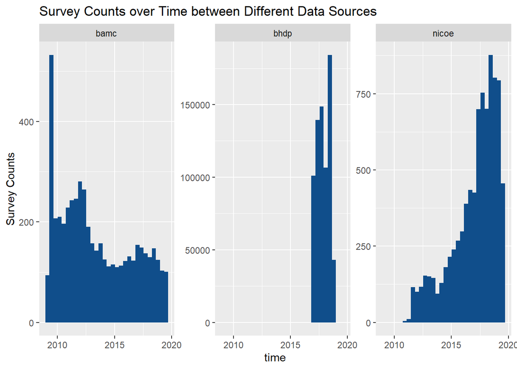

## Survey Plots

### NSI PLOTS

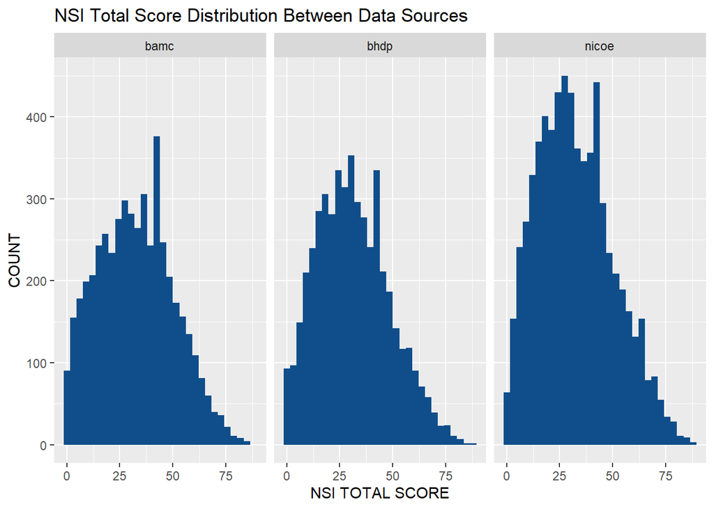

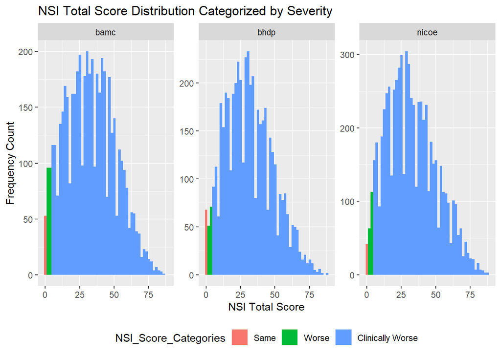

### HIT6 PLOTS

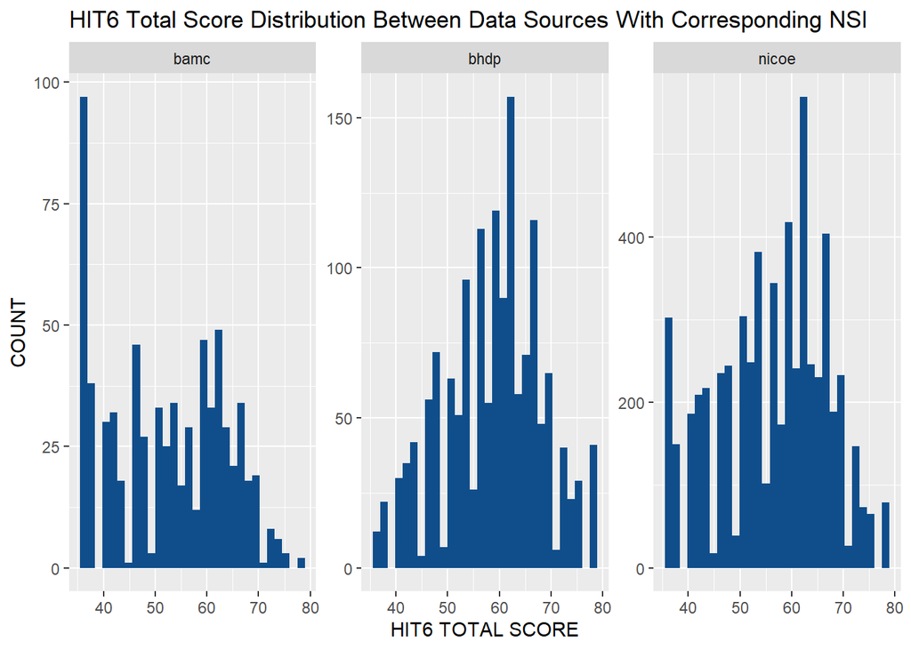

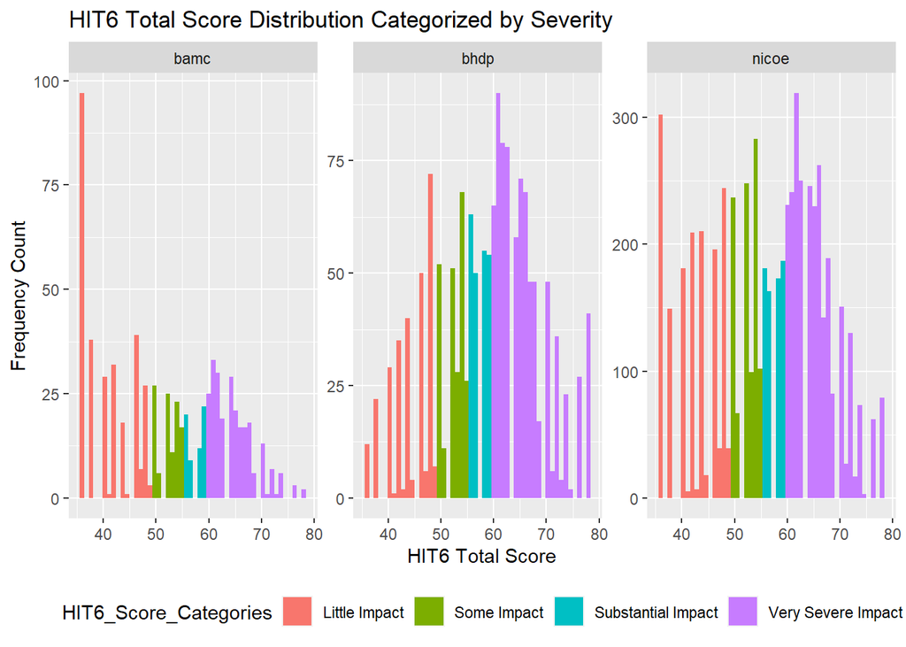

### PHQ9 PLOTS

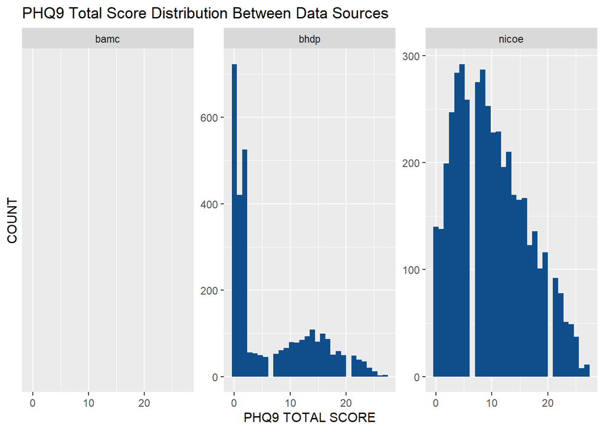

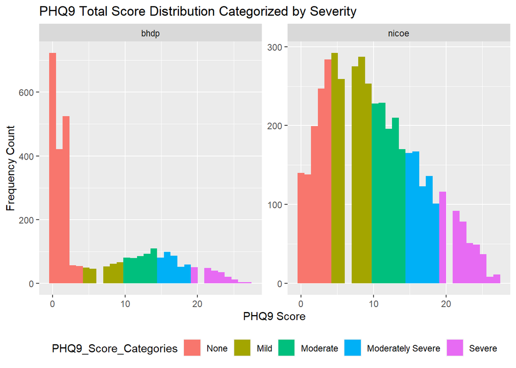

### PHQ8 PLOTS

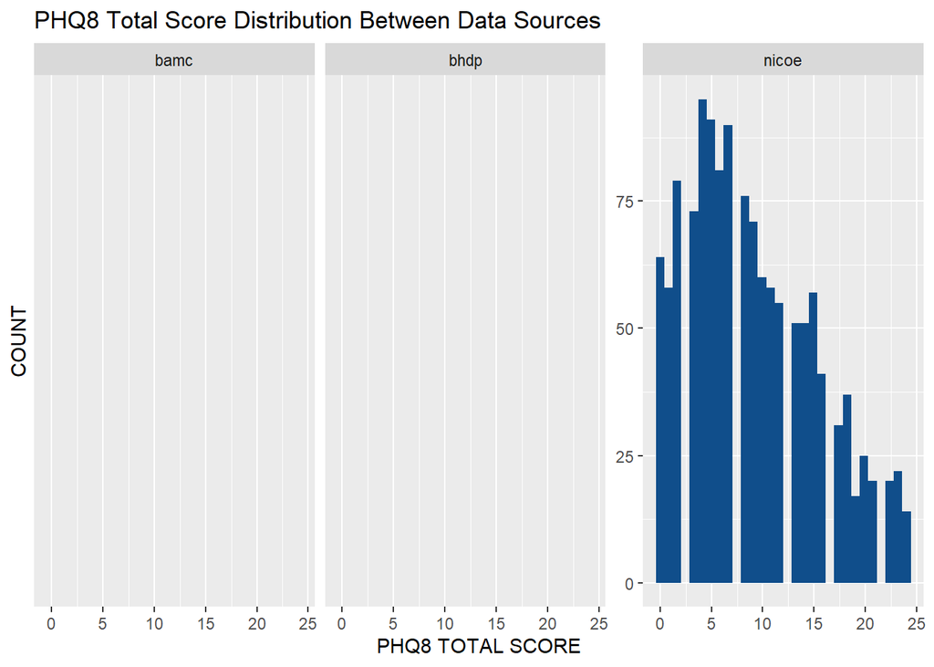

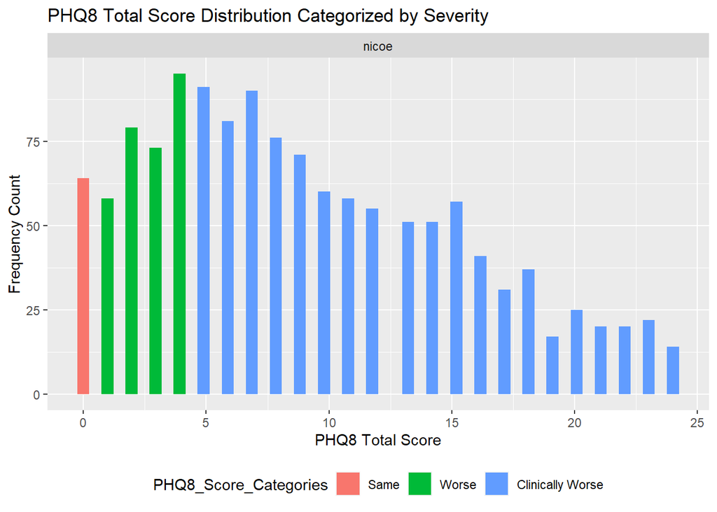

### GAD7 PLOTS

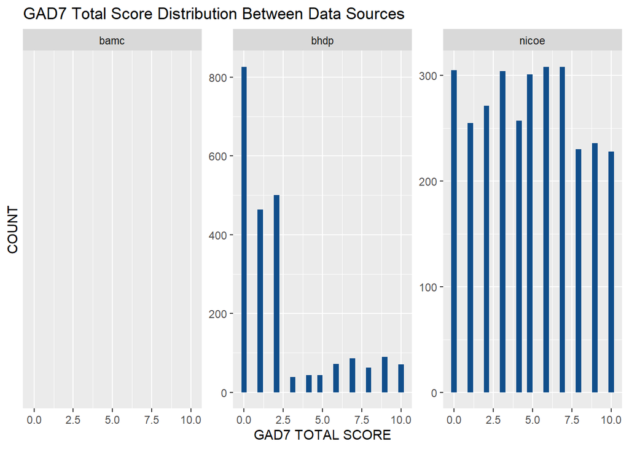

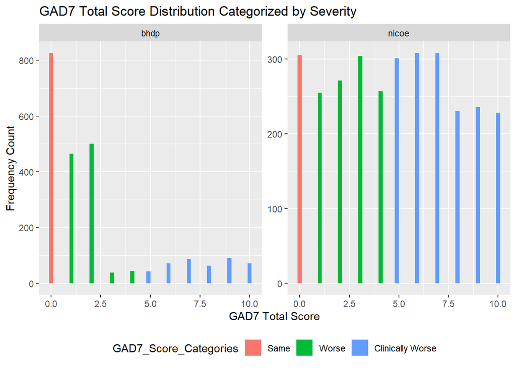

### ISI PLOTS

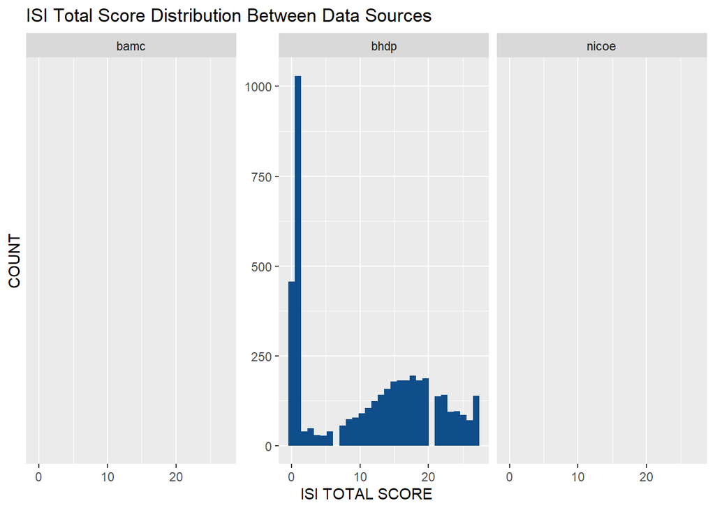

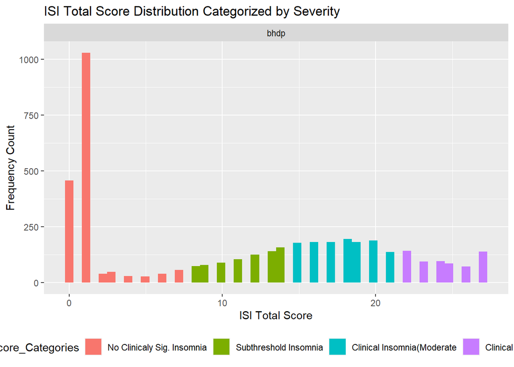

### AUDIT PLOTS

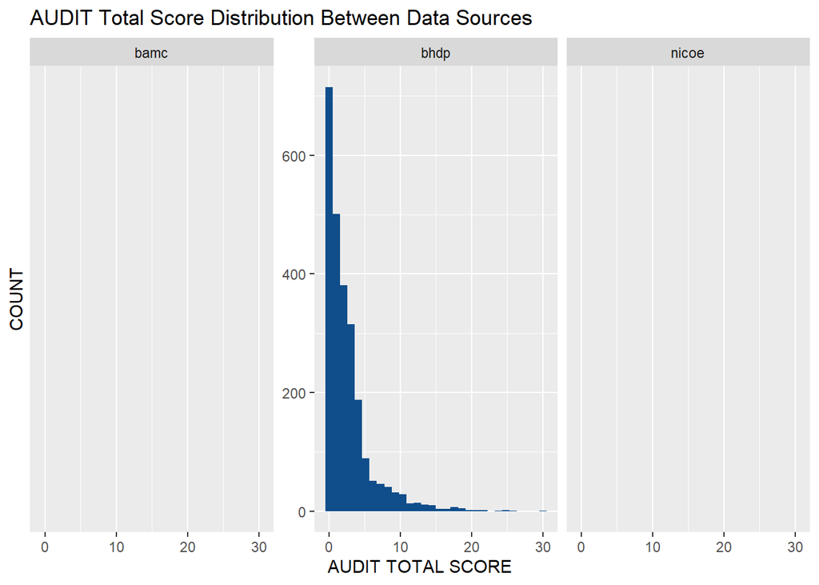

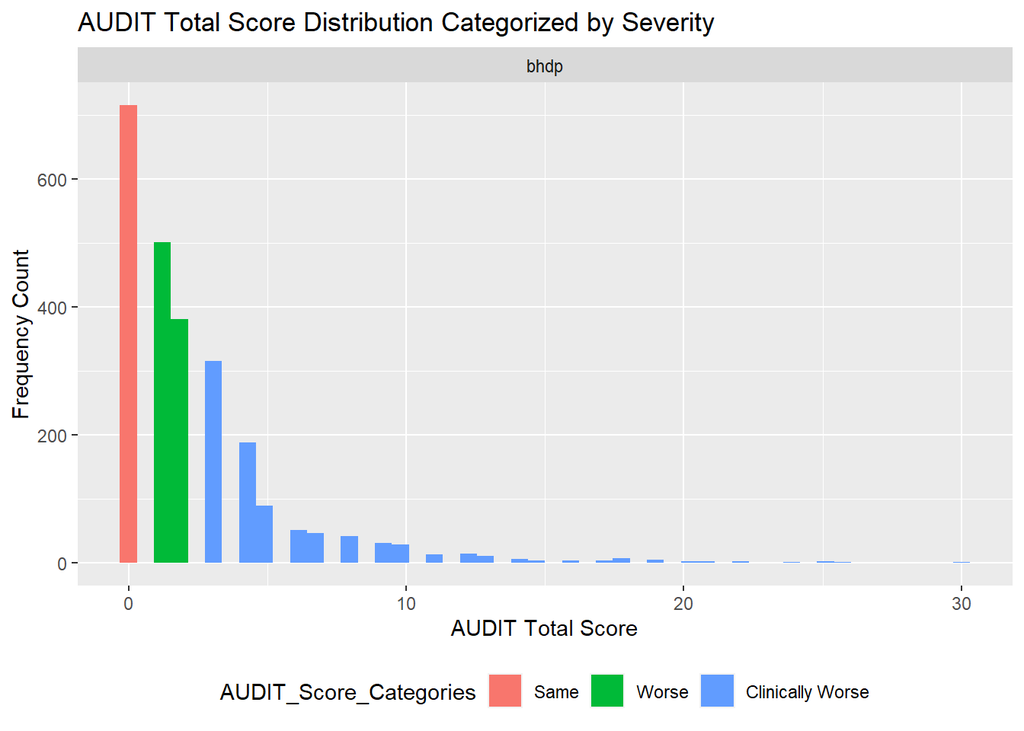

### PCL5 PLOTS

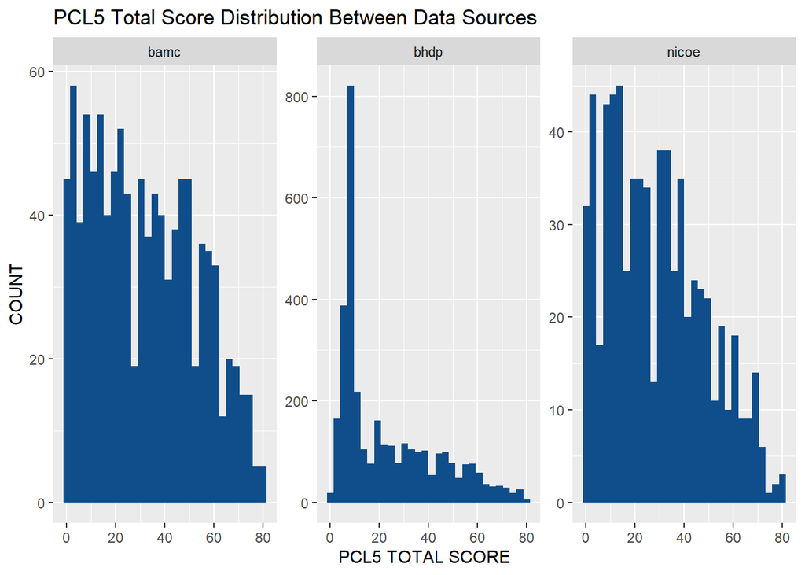

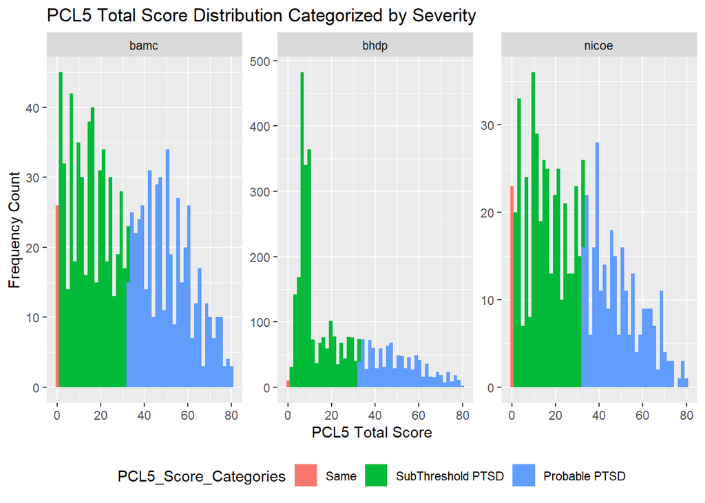

### PCLM PLOTS

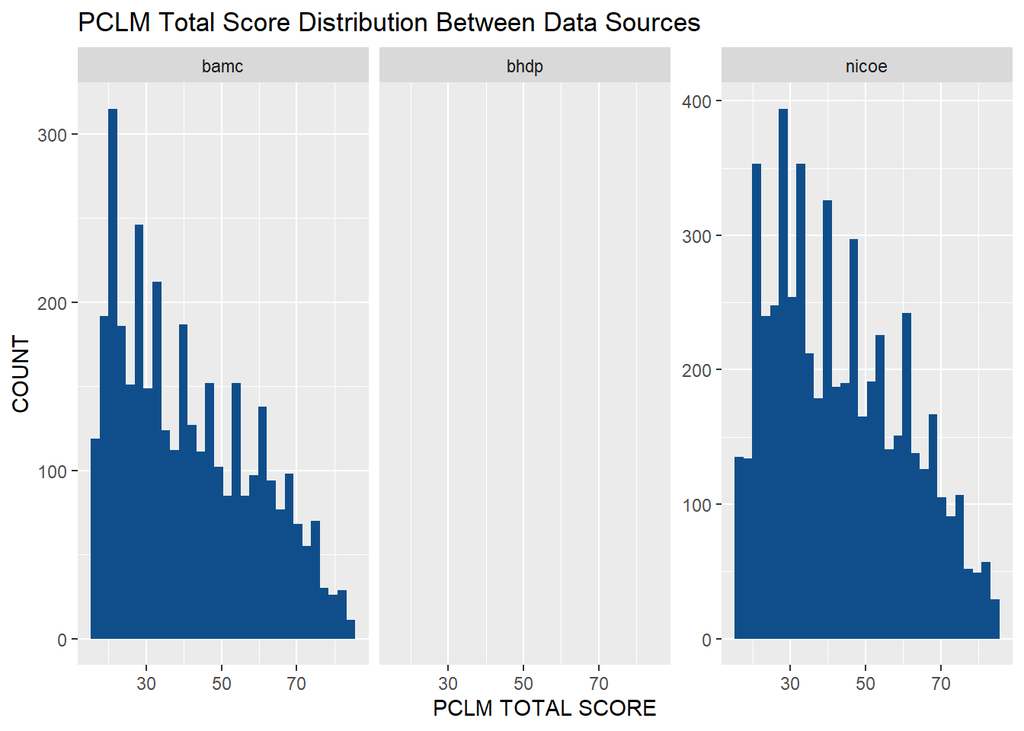

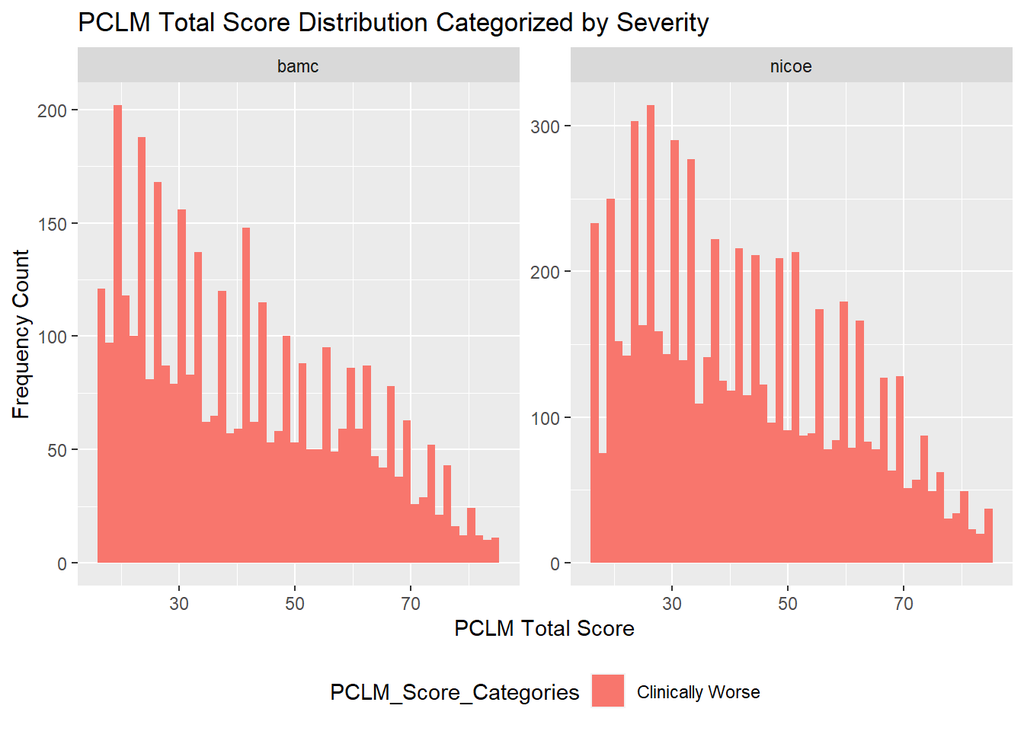

### ABC PLOTS

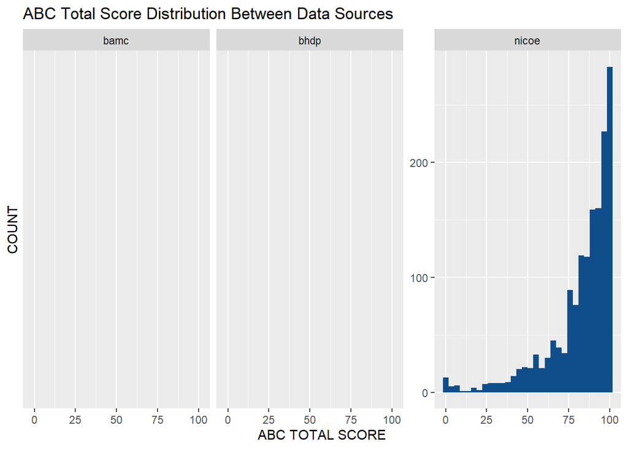

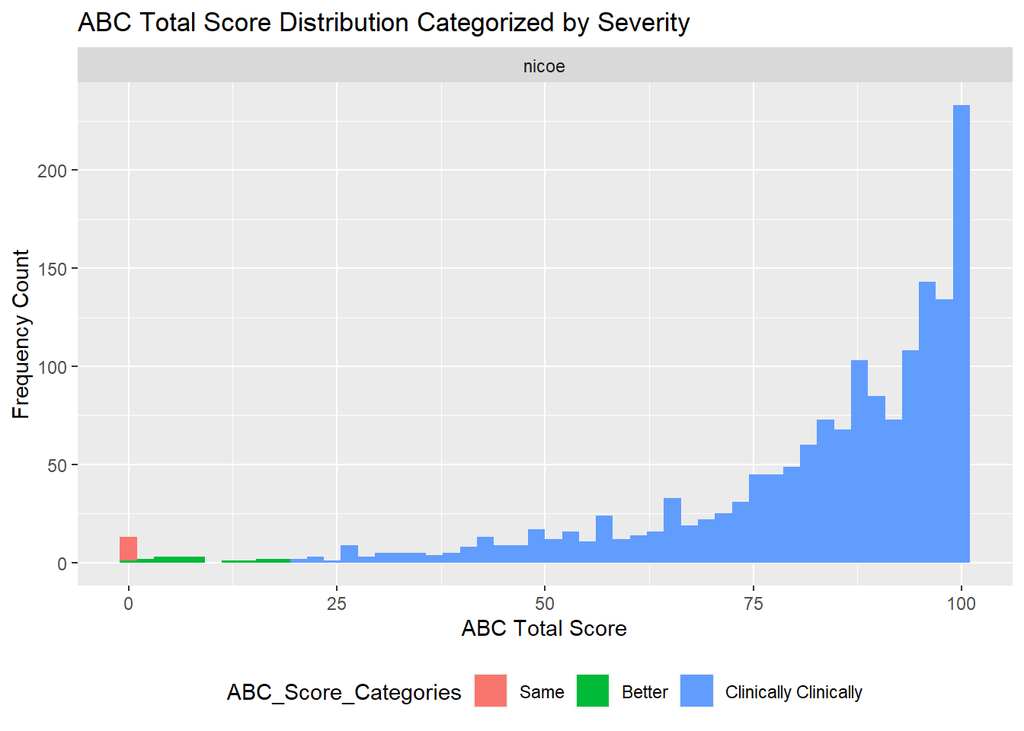

### DHI PLOTS

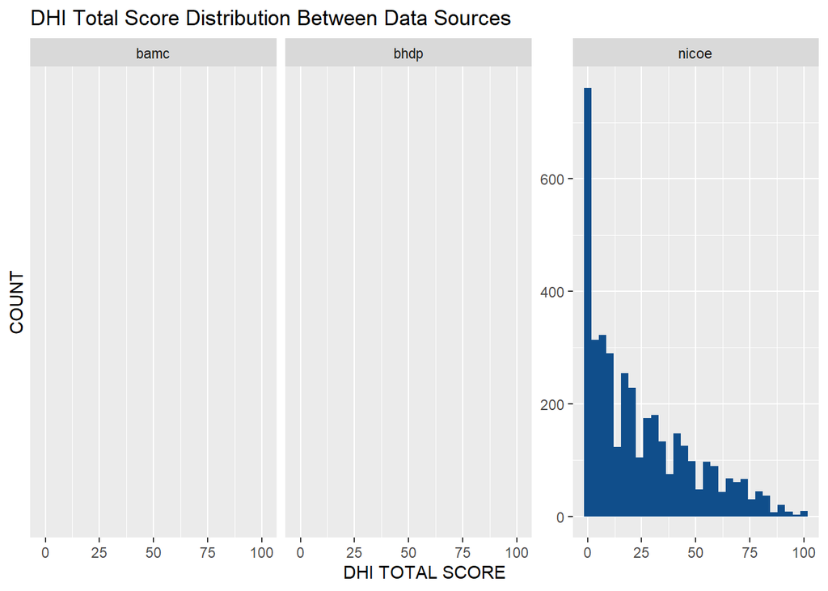

[figure not shown]

### EPWORTH PLOTS

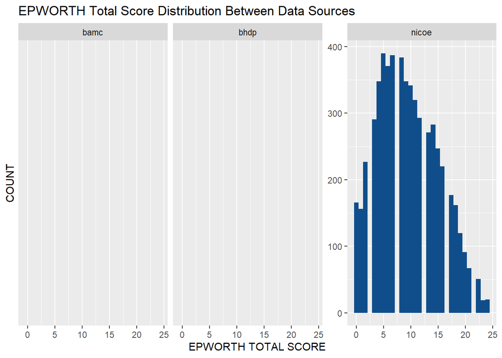

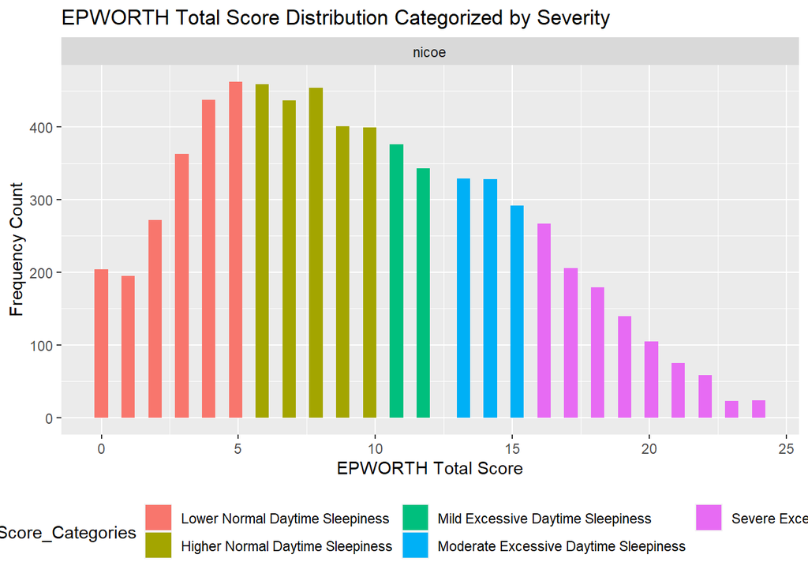

### QOL PLOTS

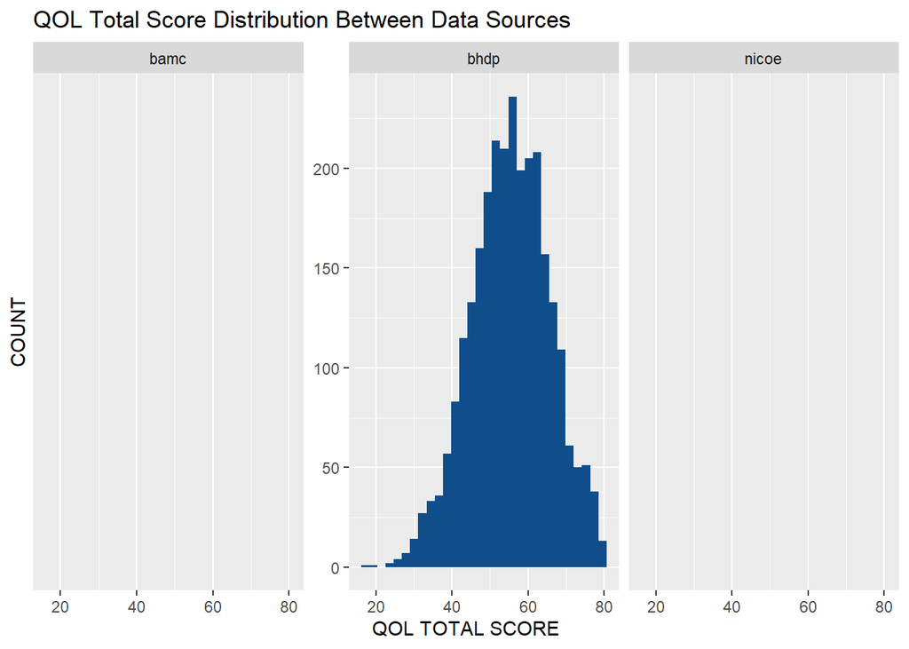

## Survey Summaries

### Survey Summary

NSI Survey means

| NSI_TotalScore | Min. : 0.00 | 1st Qu.:18.00 | Median :31.00 | Mean :32.07 | 3rd Qu.:44.00 | Max. :88.00 | NA |
| --- | --- | --- | --- | --- | --- | --- | --- |
| dhi_tot_score | Min. : 0.00 | 1st Qu.: 4.00 | Median : 18.00 | Mean : 24.34 | 3rd Qu.: 40.00 | Max. :100.00 | NA’s :12556 |
| GAD_Score | Min. : 0.000 | 1st Qu.: 1.000 | Median : 3.000 | Mean : 3.682 | 3rd Qu.: 6.000 | Max. :10.000 | NA’s :11213 |
| abc_tot_score | Min. : 0.00 | 1st Qu.: 75.62 | Median : 88.75 | Mean : 82.38 | 3rd Qu.: 96.88 | Max. :100.00 | NA’s :14933 |
| AUDIT_Score | Min. : 0.000 | 1st Qu.: 0.000 | Median : 2.000 | Mean : 2.486 | 3rd Qu.: 3.000 | Max. :30.000 | NA’s :14050 |
| pcl520_tot_score | Min. : 0.00 | 1st Qu.: 8.00 | Median :20.00 | Mean :25.91 | 3rd Qu.:41.00 | Max. :80.00 | NA’s :11347 |
| pclm_tot_score | Min. :17.00 | 1st Qu.:27.00 | Median :40.00 | Mean :42.42 | 3rd Qu.:56.00 | Max. :85.00 | NA’s :7376 |
| ISI_Score | Min. : 0.00 | 1st Qu.: 1.00 | Median :12.00 | Mean :11.13 | 3rd Qu.:19.00 | Max. :27.00 | NA’s :12155 |
| PHQ9_Score | Min. : 0.000 | 1st Qu.: 2.000 | Median : 8.000 | Mean : 8.618 | 3rd Qu.:14.000 | Max. :27.000 | NA’s :8887 |
| HIT6_Score | Min. :36.00 | 1st Qu.:48.00 | Median :58.00 | Mean :56.45 | 3rd Qu.:64.00 | Max. :78.00 | NA’s :8183 |
| epworth_tot_score | Min. : 0.000 | 1st Qu.: 5.000 | Median : 9.000 | Mean : 9.494 | 3rd Qu.:14.000 | Max. :24.000 | NA’s :10764 |
| qol_total | Min. :17.67 | 1st Qu.:48.55 | Median :55.59 | Mean :55.45 | 3rd Qu.:62.52 | Max. :80.00 | NA’s :13770 |
| data_source | Length:16515 | Class :character | Mode :character | NA | NA | NA | NA |

### NSI Summary

NSI Survey means

| NSI_TotalScore | Min. : 0.00 | 1st Qu.:18.00 | Median :31.00 | Mean :32.07 | 3rd Qu.:44.00 | Max. :88.00 | NA |
| --- | --- | --- | --- | --- | --- | --- | --- |
| NSI_Validity_10 | Min. : 0.000 | 1st Qu.: 5.000 | Median : 9.000 | Mean : 9.513 | 3rd Qu.:14.000 | Max. :21.000 | NA’s :1744 |
| NSI_F4_Sensory | Min. :0.0000 | 1st Qu.:0.5714 | Median :1.1429 | Mean :1.2115 | 3rd Qu.:1.7143 | Max. :4.0000 | NA’s :1 |
| NSI_F3_Affective | Min. :0.000 | 1st Qu.:1.000 | Median :1.833 | Mean :1.814 | 3rd Qu.:2.667 | Max. :4.000 | NA’s :5 |
| NSI_F2_Cognative | Min. :0.000 | 1st Qu.:1.000 | Median :1.750 | Mean :1.799 | 3rd Qu.:2.500 | Max. :4.000 | NA’s :4 |
| NSI_F1_Vestibular | Min. :0.0000 | 1st Qu.:0.3333 | Median :1.0000 | Mean :1.0346 | 3rd Qu.:1.6667 | Max. :4.0000 | NA’s :1 |
| NSI.Headaches_V1 | Min. :0.000 | 1st Qu.:1.000 | Median :2.000 | Mean :1.963 | 3rd Qu.:3.000 | Max. :4.000 | NA’s :1 |
| NSI.Anxious_V1 | Min. :0.000 | 1st Qu.:1.000 | Median :2.000 | Mean :1.817 | 3rd Qu.:3.000 | Max. :4.000 | NA’s :4907 |
| NSI.Appetite_Change_V1 | Min. :0.000 | 1st Qu.:0.000 | Median :1.000 | Mean :0.996 | 3rd Qu.:2.000 | Max. :4.000 | NA’s :4922 |
| NSI.Balance_V1 | Min. :0.000 | 1st Qu.:0.000 | Median :1.000 | Mean :0.985 | 3rd Qu.:2.000 | Max. :4.000 | NA’s :4901 |
| NSI.Clumsy_V1 | Min. :0.000 | 1st Qu.:0.000 | Median :1.000 | Mean :1.037 | 3rd Qu.:2.000 | Max. :4.000 | NA’s :4898 |
| NSI.Decision_Difficulty_V1 | Min. :0.000 | 1st Qu.:0.000 | Median :1.000 | Mean :1.351 | 3rd Qu.:2.000 | Max. :4.000 | NA’s :4926 |
| NSI.Depressed_V1 | Min. :0.000 | 1st Qu.:0.000 | Median :1.000 | Mean :1.254 | 3rd Qu.:2.000 | Max. :4.000 | NA’s :4981 |
| NSI.Distracted_V1 | Min. :0.000 | 1st Qu.:1.000 | Median :2.000 | Mean :2.009 | 3rd Qu.:3.000 | Max. :4.000 | NA’s :4895 |
| NSI.Dizzy_V1 | Min. :0.00 | 1st Qu.:0.00 | Median :1.00 | Mean :1.08 | 3rd Qu.:2.00 | Max. :4.00 | NA’s :4896 |
| NSI.Fatigue_V1 | Min. :0.000 | 1st Qu.:1.000 | Median :2.000 | Mean :1.926 | 3rd Qu.:3.000 | Max. :4.000 | NA’s :4896 |
| NSI.Forgetfulness_V1 | Min. :0.000 | 1st Qu.:1.000 | Median :2.000 | Mean :2.135 | 3rd Qu.:3.000 | Max. :4.000 | NA’s :4895 |
| NSI.Hearing_Difficulty | Min. :0.000 | 1st Qu.:0.000 | Median :1.000 | Mean :1.395 | 3rd Qu.:2.000 | Max. :4.000 | NA’s :4896 |
| NSI.Irritability_V1 | Min. :0.000 | 1st Qu.:1.000 | Median :2.000 | Mean :1.939 | 3rd Qu.:3.000 | Max. :4.000 | NA’s :4900 |
| NSI.Light_Sensitivity_V1 | Min. :0.000 | 1st Qu.:0.000 | Median :1.000 | Mean :1.443 | 3rd Qu.:2.000 | Max. :4.000 | NA’s :4896 |
| NSI.Nausea_V1 | Min. :0.000 | 1st Qu.:0.000 | Median :0.000 | Mean :0.673 | 3rd Qu.:1.000 | Max. :4.000 | NA’s :4895 |
| NSI.Noise_Sensitivity_V1 | Min. :0.000 | 1st Qu.:0.000 | Median :1.000 | Mean :1.382 | 3rd Qu.:2.000 | Max. :4.000 | NA’s :4895 |
| NSI.Numbness_V1 | Min. :0.000 | 1st Qu.:0.000 | Median :1.000 | Mean :1.343 | 3rd Qu.:2.000 | Max. :4.000 | NA’s :4894 |
| NSI.Overwhelmed_V1 | Min. :0.000 | 1st Qu.:1.000 | Median :2.000 | Mean :1.658 | 3rd Qu.:3.000 | Max. :4.000 | NA’s :4900 |
| NSI.Sleep_Difficulty_V1 | Min. :0.000 | 1st Qu.:1.000 | Median :2.000 | Mean :2.222 | 3rd Qu.:3.000 | Max. :4.000 | NA’s :4899 |
| NSI.Slow_Thinking_V1 | Min. :0.00 | 1st Qu.:1.00 | Median :2.00 | Mean :1.67 | 3rd Qu.:3.00 | Max. :4.00 | NA’s :4896 |
| NSI.Taste_Smell_Change_V1 | Min. :0.000 | 1st Qu.:0.000 | Median :0.000 | Mean :0.458 | 3rd Qu.:1.000 | Max. :4.000 | NA’s :4899 |
| NSI.Vision_Problems_V1 | Min. :0.000 | 1st Qu.:0.000 | Median :1.000 | Mean :1.163 | 3rd Qu.:2.000 | Max. :4.000 | NA’s :4895 |

## Correlation Plots

### Cor Tables

Self Report Correlations

|  | NSI_TotalScore | NSI_Validity_10 | NSI_F4_Sensory | NSI_F3_Affective | NSI_F2_Cognative | NSI_F1_Vestibular | pcl520_tot_score | HIT6_Score | pclm_tot_score | dhi_tot_score | GAD_Score | PHQ9_Score | phq8_tot_score | ISI_Score | AUDIT_Score | epworth_tot_score | abc_tot_score | qol_total |
| --- | --- | --- | --- | --- | --- | --- | --- | --- | --- | --- | --- | --- | --- | --- | --- | --- | --- | --- |
| NSI_TotalScore | 1.000 | 0.919 | 0.885 | 0.913 | 0.875 | 0.769 | 0.645 | 0.698 | 0.819 | 0.676 | 0.470 | 0.759 | 0.828 | 0.596 | 0.060 | 0.373 | -0.430 | -0.700 |
| NSI_Validity_10 | 0.919 | 1.000 | 0.827 | 0.705 | 0.775 | 0.786 | 0.504 | 0.576 | 0.654 | 0.571 | 0.370 | 0.557 | 0.647 | 0.432 | 0.063 | 0.307 | -0.347 | -0.546 |
| NSI_F4_Sensory | 0.885 | 0.827 | 1.000 | 0.697 | 0.650 | 0.704 | 0.541 | 0.714 | 0.674 | 0.663 | 0.308 | 0.582 | 0.647 | 0.465 | -0.001 | 0.297 | -0.434 | -0.514 |
| NSI_F3_Affective | 0.913 | 0.705 | 0.697 | 1.000 | 0.792 | 0.583 | 0.649 | 0.604 | 0.836 | 0.519 | 0.549 | 0.792 | 0.856 | 0.653 | 0.094 | 0.359 | -0.296 | -0.737 |
| NSI_F2_Cognative | 0.875 | 0.775 | 0.650 | 0.792 | 1.000 | 0.596 | 0.541 | 0.555 | 0.715 | 0.512 | 0.381 | 0.666 | 0.748 | 0.487 | 0.080 | 0.341 | -0.292 | -0.634 |
| NSI_F1_Vestibular | 0.769 | 0.786 | 0.704 | 0.583 | 0.596 | 1.000 | 0.432 | 0.550 | 0.555 | 0.722 | 0.234 | 0.503 | 0.569 | 0.385 | 0.008 | 0.299 | -0.543 | -0.453 |
| pcl520_tot_score | 0.645 | 0.504 | 0.541 | 0.649 | 0.541 | 0.432 | 1.000 | 0.398 | 0.976 | 0.520 | 0.428 | 0.635 | 0.786 | 0.397 | 0.135 | 0.413 | -0.302 | -0.356 |
| HIT6_Score | 0.698 | 0.576 | 0.714 | 0.604 | 0.555 | 0.550 | 0.398 | 1.000 | 0.596 | 0.577 | 0.261 | 0.512 | 0.585 | 0.448 | -0.088 | 0.299 | -0.352 | -0.481 |
| pclm_tot_score | 0.819 | 0.654 | 0.674 | 0.836 | 0.715 | 0.555 | 0.976 | 0.596 | 1.000 | 0.541 | 0.623 | 0.775 | 0.829 | NA | NA | 0.294 | -0.359 | NA |
| dhi_tot_score | 0.676 | 0.571 | 0.663 | 0.519 | 0.512 | 0.722 | 0.520 | 0.577 | 0.541 | 1.000 | 0.227 | 0.527 | 0.524 | NA | NA | 0.240 | -0.656 | NA |
| GAD_Score | 0.470 | 0.370 | 0.308 | 0.549 | 0.381 | 0.234 | 0.428 | 0.261 | 0.623 | 0.227 | 1.000 | 0.610 | 0.627 | 0.276 | 0.093 | 0.269 | -0.115 | -0.358 |
| PHQ9_Score | 0.759 | 0.557 | 0.582 | 0.792 | 0.666 | 0.503 | 0.635 | 0.512 | 0.775 | 0.527 | 0.610 | 1.000 | 0.997 | 0.535 | 0.070 | 0.356 | -0.305 | -0.667 |
| phq8_tot_score | 0.828 | 0.647 | 0.647 | 0.856 | 0.748 | 0.569 | 0.786 | 0.585 | 0.829 | 0.524 | 0.627 | 0.997 | 1.000 | NA | NA | 0.389 | -0.388 | NA |
| ISI_Score | 0.596 | 0.432 | 0.465 | 0.653 | 0.487 | 0.385 | 0.397 | 0.448 | NA | NA | 0.276 | 0.535 | NA | 1.000 | 0.052 | NA | NA | -0.505 |
| AUDIT_Score | 0.060 | 0.063 | -0.001 | 0.094 | 0.080 | 0.008 | 0.135 | -0.088 | NA | NA | 0.093 | 0.070 | NA | 0.052 | 1.000 | NA | NA | -0.107 |
| epworth_tot_score | 0.373 | 0.307 | 0.297 | 0.359 | 0.341 | 0.299 | 0.413 | 0.299 | 0.294 | 0.240 | 0.269 | 0.356 | 0.389 | NA | NA | 1.000 | -0.163 | NA |
| abc_tot_score | -0.430 | -0.347 | -0.434 | -0.296 | -0.292 | -0.543 | -0.302 | -0.352 | -0.359 | -0.656 | -0.115 | -0.305 | -0.388 | NA | NA | -0.163 | 1.000 | NA |
| qol_total | -0.700 | -0.546 | -0.514 | -0.737 | -0.634 | -0.453 | -0.356 | -0.481 | NA | NA | -0.358 | -0.667 | NA | -0.505 | -0.107 | NA | NA | 1.000 |

Self Report Correlation Counts

|  | NSI_TotalScore | NSI_Validity_10 | NSI_F4_Sensory | NSI_F3_Affective | NSI_F2_Cognative | NSI_F1_Vestibular | pcl520_tot_score | HIT6_Score | pclm_tot_score | dhi_tot_score | GAD_Score | PHQ9_Score | phq8_tot_score | ISI_Score | AUDIT_Score | epworth_tot_score | abc_tot_score | qol_total |
| --- | --- | --- | --- | --- | --- | --- | --- | --- | --- | --- | --- | --- | --- | --- | --- | --- | --- | --- |
| NSI_TotalScore | 16515 | 14771 | 16514 | 16510 | 16511 | 16514 | 5168 | 8332 | 9139 | 3959 | 5302 | 7628 | 1337 | 4360 | 2465 | 5751 | 1582 | 2745 |
| NSI_Validity_10 | 14771 | 14771 | 14770 | 14766 | 14767 | 14770 | 4605 | 7467 | 8183 | 3450 | 5194 | 6865 | 1195 | 3955 | 2233 | 5133 | 1423 | 2524 |
| NSI_F4_Sensory | 16514 | 14770 | 16514 | 16510 | 16511 | 16513 | 5168 | 8332 | 9139 | 3959 | 5302 | 7628 | 1337 | 4360 | 2465 | 5751 | 1582 | 2745 |
| NSI_F3_Affective | 16510 | 14766 | 16510 | 16510 | 16510 | 16509 | 5168 | 8332 | 9139 | 3959 | 5302 | 7628 | 1337 | 4359 | 2465 | 5751 | 1582 | 2745 |
| NSI_F2_Cognative | 16511 | 14767 | 16511 | 16510 | 16511 | 16510 | 5168 | 8332 | 9139 | 3959 | 5302 | 7628 | 1337 | 4360 | 2465 | 5751 | 1582 | 2745 |
| NSI_F1_Vestibular | 16514 | 14770 | 16513 | 16509 | 16510 | 16514 | 5168 | 8332 | 9139 | 3959 | 5302 | 7627 | 1337 | 4360 | 2465 | 5751 | 1582 | 2745 |
| pcl520_tot_score | 5168 | 4605 | 5168 | 5168 | 5168 | 5168 | 5168 | 1666 | 6 | 327 | 2215 | 2754 | 425 | 3117 | 2157 | 185 | 114 | 2742 |
| HIT6_Score | 8332 | 7467 | 8332 | 8332 | 8332 | 8332 | 1666 | 8332 | 6132 | 3936 | 3724 | 5593 | 1105 | 1379 | 935 | 5653 | 1568 | 1065 |
| pclm_tot_score | 9139 | 8183 | 9139 | 9139 | 9139 | 9139 | 6 | 6132 | 9139 | 3472 | 2584 | 4271 | 776 | 0 | 0 | 5422 | 1431 | 0 |
| dhi_tot_score | 3959 | 3450 | 3959 | 3959 | 3959 | 3959 | 327 | 3936 | 3472 | 3959 | 1879 | 3349 | 544 | 0 | 0 | 3635 | 1429 | 0 |
| GAD_Score | 5302 | 5194 | 5302 | 5302 | 5302 | 5302 | 2215 | 3724 | 2584 | 1879 | 5302 | 4211 | 709 | 2115 | 1724 | 2732 | 842 | 1616 |
| PHQ9_Score | 7628 | 6865 | 7628 | 7628 | 7628 | 7627 | 2754 | 5593 | 4271 | 3349 | 4211 | 7628 | 3 | 2708 | 2339 | 4463 | 1335 | 2007 |
| phq8_tot_score | 1337 | 1195 | 1337 | 1337 | 1337 | 1337 | 425 | 1105 | 776 | 544 | 709 | 3 | 1337 | 0 | 0 | 801 | 212 | 0 |
| ISI_Score | 4360 | 3955 | 4360 | 4359 | 4360 | 4360 | 3117 | 1379 | 0 | 0 | 2115 | 2708 | 0 | 4360 | 2350 | 0 | 0 | 2558 |
| AUDIT_Score | 2465 | 2233 | 2465 | 2465 | 2465 | 2465 | 2157 | 935 | 0 | 0 | 1724 | 2339 | 0 | 2350 | 2465 | 0 | 0 | 1741 |
| epworth_tot_score | 5751 | 5133 | 5751 | 5751 | 5751 | 5751 | 185 | 5653 | 5422 | 3635 | 2732 | 4463 | 801 | 0 | 0 | 5751 | 1570 | 0 |
| abc_tot_score | 1582 | 1423 | 1582 | 1582 | 1582 | 1582 | 114 | 1568 | 1431 | 1429 | 842 | 1335 | 212 | 0 | 0 | 1570 | 1582 | 0 |
| qol_total | 2745 | 2524 | 2745 | 2745 | 2745 | 2745 | 2742 | 1065 | 0 | 0 | 1616 | 2007 | 0 | 2558 | 1741 | 0 | 0 | 2745 |

Self Report Correlation P Values

|  | NSI_TotalScore | NSI_Validity_10 | NSI_F4_Sensory | NSI_F3_Affective | NSI_F2_Cognative | NSI_F1_Vestibular | pcl520_tot_score | HIT6_Score | pclm_tot_score | dhi_tot_score | GAD_Score | PHQ9_Score | phq8_tot_score | ISI_Score | AUDIT_Score | epworth_tot_score | abc_tot_score | qol_total |
| --- | --- | --- | --- | --- | --- | --- | --- | --- | --- | --- | --- | --- | --- | --- | --- | --- | --- | --- |
| NSI_TotalScore | 1.00000*** | 0.91874*** | 0.88541*** | 0.91258*** | 0.87454*** | 0.76939*** | 0.64453*** | 0.69780*** | 0.81929*** | 0.67632*** | 0.47009*** | 0.75865*** | 0.82759*** | 0.59650*** | 0.05982* | 0.37309*** | -0.43033*** | -0.70003*** |
|  | (0.00000) | (0.00000) | (0.00000) | (0.00000) | (0.00000) | (0.00000) | (0.00000) | (0.00000) | (0.00000) | (0.00000) | (0.00000) | (0.00000) | (0.00000) | (0.00000) | (0.02076) | (0.00000) | (0.00000) | (0.00000) |
| NSI_Validity_10 | 0.91874*** | 1.00000*** | 0.82711*** | 0.70521*** | 0.77501*** | 0.78626*** | 0.50368*** | 0.57602*** | 0.65435*** | 0.57055*** | 0.37006*** | 0.55714*** | 0.64742*** | 0.43242*** | 0.06275* | 0.30710*** | -0.34746*** | -0.54584*** |
|  | (0.00000) | (0.00000) | (0.00000) | (0.00000) | (0.00000) | (0.00000) | (0.00000) | (0.00000) | (0.00000) | (0.00000) | (0.00000) | (0.00000) | (0.00000) | (0.00000) | (0.02076) | (0.00000) | (0.00000) | (0.00000) |
| NSI_F4_Sensory | 0.88541*** | 0.82711*** | 1.00000*** | 0.69690*** | 0.65019*** | 0.70447*** | 0.54076*** | 0.71373*** | 0.67405*** | 0.66323*** | 0.30784*** | 0.58171*** | 0.64709*** | 0.46498*** | -0.00060 | 0.29740*** | -0.43424*** | -0.51432*** |
|  | (0.00000) | (0.00000) | (0.00000) | (0.00000) | (0.00000) | (0.00000) | (0.00000) | (0.00000) | (0.00000) | (0.00000) | (0.00000) | (0.00000) | (0.00000) | (0.00000) | (1.00000) | (0.00000) | (0.00000) | (0.00000) |
| NSI_F3_Affective | 0.91258*** | 0.70521*** | 0.69690*** | 1.00000*** | 0.79240*** | 0.58344*** | 0.64854*** | 0.60402*** | 0.83650*** | 0.51870*** | 0.54906*** | 0.79201*** | 0.85647*** | 0.65335*** | 0.09401*** | 0.35867*** | -0.29589*** | -0.73728*** |
|  | (0.00000) | (0.00000) | (0.00000) | (0.00000) | (0.00000) | (0.00000) | (0.00000) | (0.00000) | (0.00000) | (0.00000) | (0.00000) | (0.00000) | (0.00000) | (0.00000) | (0.00004) | (0.00000) | (0.00000) | (0.00000) |
| NSI_F2_Cognative | 0.87454*** | 0.77501*** | 0.65019*** | 0.79240*** | 1.00000*** | 0.59644*** | 0.54083*** | 0.55472*** | 0.71487*** | 0.51157*** | 0.38067*** | 0.66643*** | 0.74779*** | 0.48673*** | 0.08020*** | 0.34121*** | -0.29248*** | -0.63449*** |
|  | (0.00000) | (0.00000) | (0.00000) | (0.00000) | (0.00000) | (0.00000) | (0.00000) | (0.00000) | (0.00000) | (0.00000) | (0.00000) | (0.00000) | (0.00000) | (0.00000) | (0.00087) | (0.00000) | (0.00000) | (0.00000) |
| NSI_F1_Vestibular | 0.76939*** | 0.78626*** | 0.70447*** | 0.58344*** | 0.59644*** | 1.00000*** | 0.43220*** | 0.54977*** | 0.55535*** | 0.72151*** | 0.23448*** | 0.50331*** | 0.56924*** | 0.38473*** | 0.00839 | 0.29870*** | -0.54272*** | -0.45338*** |
|  | (0.00000) | (0.00000) | (0.00000) | (0.00000) | (0.00000) | (0.00000) | (0.00000) | (0.00000) | (0.00000) | (0.00000) | (0.00000) | (0.00000) | (0.00000) | (0.00000) | (1.00000) | (0.00000) | (0.00000) | (0.00000) |
| pcl520_tot_score | 0.64453*** | 0.50368*** | 0.54076*** | 0.64854*** | 0.54083*** | 0.43220*** | 1.00000*** | 0.39808*** | 0.97586** | 0.51953*** | 0.42810*** | 0.63537*** | 0.78557*** | 0.39732*** | 0.13540*** | 0.41349*** | -0.30182** | -0.35612*** |
|  | (0.00000) | (0.00000) | (0.00000) | (0.00000) | (0.00000) | (0.00000) | (0.00000) | (0.00000) | (0.00834) | (0.00000) | (0.00000) | (0.00000) | (0.00000) | (0.00000) | (0.00000) | (0.00000) | (0.00880) | (0.00000) |
| HIT6_Score | 0.69780*** | 0.57602*** | 0.71373*** | 0.60402*** | 0.55472*** | 0.54977*** | 0.39808*** | 1.00000*** | 0.59551*** | 0.57693*** | 0.26094*** | 0.51227*** | 0.58466*** | 0.44780*** | -0.08790* | 0.29895*** | -0.35216*** | -0.48135*** |
|  | (0.00000) | (0.00000) | (0.00000) | (0.00000) | (0.00000) | (0.00000) | (0.00000) | (0.00000) | (0.00000) | (0.00000) | (0.00000) | (0.00000) | (0.00000) | (0.00000) | (0.03578) | (0.00000) | (0.00000) | (0.00000) |
| pclm_tot_score | 0.81929*** | 0.65435*** | 0.67405*** | 0.83650*** | 0.71487*** | 0.55535*** | 0.97586*** | 0.59551*** | 1.00000*** | 0.54136*** | 0.62267*** | 0.77529*** | 0.82944*** | NANA | NANA | 0.29383*** | -0.35883*** | NANA |
|  | (0.00000) | (0.00000) | (0.00000) | (0.00000) | (0.00000) | (0.00000) | (0.00087) | (0.00000) | (0.00000) | (0.00000) | (0.00000) | (0.00000) | (0.00000) | ( NaN) | ( NaN) | (0.00000) | (0.00000) | ( NaN) |
| dhi_tot_score | 0.67632*** | 0.57055*** | 0.66323*** | 0.51870*** | 0.51157*** | 0.72151*** | 0.51953*** | 0.57693*** | 0.54136*** | 1.00000*** | 0.22733*** | 0.52733*** | 0.52377*** | NANA | NANA | 0.23967*** | -0.65596*** | NANA |
|  | (0.00000) | (0.00000) | (0.00000) | (0.00000) | (0.00000) | (0.00000) | (0.00000) | (0.00000) | (0.00000) | (0.00000) | (0.00000) | (0.00000) | (0.00000) | ( NaN) | ( NaN) | (0.00000) | (0.00000) | ( NaN) |
| GAD_Score | 0.47009*** | 0.37006*** | 0.30784*** | 0.54906*** | 0.38067*** | 0.23448*** | 0.42810*** | 0.26094*** | 0.62267*** | 0.22733*** | 1.00000*** | 0.60952*** | 0.62748*** | 0.27623*** | 0.09338** | 0.26936*** | -0.11533** | -0.35823*** |
|  | (0.00000) | (0.00000) | (0.00000) | (0.00000) | (0.00000) | (0.00000) | (0.00000) | (0.00000) | (0.00000) | (0.00000) | (0.00000) | (0.00000) | (0.00000) | (0.00000) | (0.00124) | (0.00000) | (0.00834) | (0.00000) |
| PHQ9_Score | 0.75865*** | 0.55714*** | 0.58171*** | 0.79201*** | 0.66643*** | 0.50331*** | 0.63537*** | 0.51227*** | 0.77529*** | 0.52733*** | 0.60952*** | 1.00000*** | 0.99662 | 0.53523*** | 0.06959** | 0.35584*** | -0.30536*** | -0.66734*** |
|  | (0.00000) | (0.00000) | (0.00000) | (0.00000) | (0.00000) | (0.00000) | (0.00000) | (0.00000) | (0.00000) | (0.00000) | (0.00000) | (0.00000) | (0.15717) | (0.00000) | (0.00834) | (0.00000) | (0.00000) | (0.00000) |
| phq8_tot_score | 0.82759*** | 0.64742*** | 0.64709*** | 0.85647*** | 0.74779*** | 0.56924*** | 0.78557*** | 0.58466*** | 0.82944*** | 0.52377*** | 0.62748*** | 0.99662 | 1.00000*** | NANA | NANA | 0.38880*** | -0.38768*** | NANA |
|  | (0.00000) | (0.00000) | (0.00000) | (0.00000) | (0.00000) | (0.00000) | (0.00000) | (0.00000) | (0.00000) | (0.00000) | (0.00000) | (0.05239) | (0.00000) | ( NaN) | ( NaN) | (0.00000) | (0.00000) | ( NaN) |
| ISI_Score | 0.59650*** | 0.43242*** | 0.46498*** | 0.65335*** | 0.48673*** | 0.38473*** | 0.39732*** | 0.44780*** | NANA | NANA | 0.27623*** | 0.53523*** | NANA | 1.00000*** | 0.05199* | NANA | NANA | -0.50509*** |
|  | (0.00000) | (0.00000) | (0.00000) | (0.00000) | (0.00000) | (0.00000) | (0.00000) | (0.00000) | ( NaN) | ( NaN) | (0.00000) | (0.00000) | ( NaN) | (0.00000) | (0.04686) | ( NaN) | ( NaN) | (0.00000) |
| AUDIT_Score | 0.05982** | 0.06275** | -0.00060 | 0.09401*** | 0.08020*** | 0.00839 | 0.13540*** | -0.08790** | NANA | NANA | 0.09338*** | 0.06959*** | NANA | 0.05199* | 1.00000*** | NANA | NANA | -0.10695*** |
|  | (0.00297) | (0.00301) | (0.97644) | (0.00000) | (0.00007) | (0.67717) | (0.00000) | (0.00716) | ( NaN) | ( NaN) | (0.00010) | (0.00076) | ( NaN) | (0.01172) | (0.00000) | ( NaN) | ( NaN) | (0.00011) |
| epworth_tot_score | 0.37309*** | 0.30710*** | 0.29740*** | 0.35867*** | 0.34121*** | 0.29870*** | 0.41349*** | 0.29895*** | 0.29383*** | 0.23967*** | 0.26936*** | 0.35584*** | 0.38880*** | NANA | NANA | 1.00000*** | -0.16322*** | NANA |
|  | (0.00000) | (0.00000) | (0.00000) | (0.00000) | (0.00000) | (0.00000) | (0.00000) | (0.00000) | (0.00000) | (0.00000) | (0.00000) | (0.00000) | (0.00000) | ( NaN) | ( NaN) | (0.00000) | (0.00000) | ( NaN) |
| abc_tot_score | -0.43033*** | -0.34746*** | -0.43424*** | -0.29589*** | -0.29248*** | -0.54272*** | -0.30182** | -0.35216*** | -0.35883*** | -0.65596*** | -0.11533*** | -0.30536*** | -0.38768*** | NANA | NANA | -0.16322*** | 1.00000*** | NANA |
|  | (0.00000) | (0.00000) | (0.00000) | (0.00000) | (0.00000) | (0.00000) | (0.00110) | (0.00000) | (0.00000) | (0.00000) | (0.00080) | (0.00000) | (0.00000) | ( NaN) | ( NaN) | (0.00000) | (0.00000) | ( NaN) |
| qol_total | -0.70003*** | -0.54584*** | -0.51432*** | -0.73728*** | -0.63449*** | -0.45338*** | -0.35612*** | -0.48135*** | NANA | NANA | -0.35823*** | -0.66734*** | NANA | -0.50509*** | -0.10695*** | NANA | NANA | 1.00000*** |
|  | (0.00000) | (0.00000) | (0.00000) | (0.00000) | (0.00000) | (0.00000) | (0.00000) | (0.00000) | ( NaN) | ( NaN) | (0.00000) | (0.00000) | ( NaN) | (0.00000) | (0.00001) | ( NaN) | ( NaN) | (0.00000) |

### NSI and HIT6

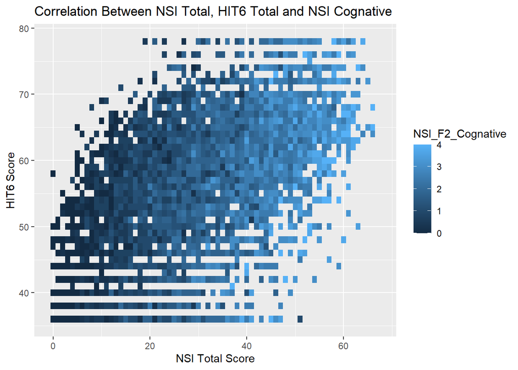

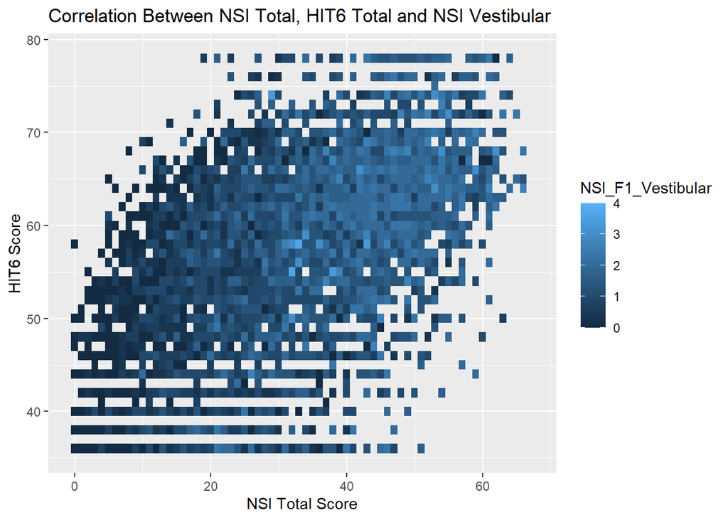

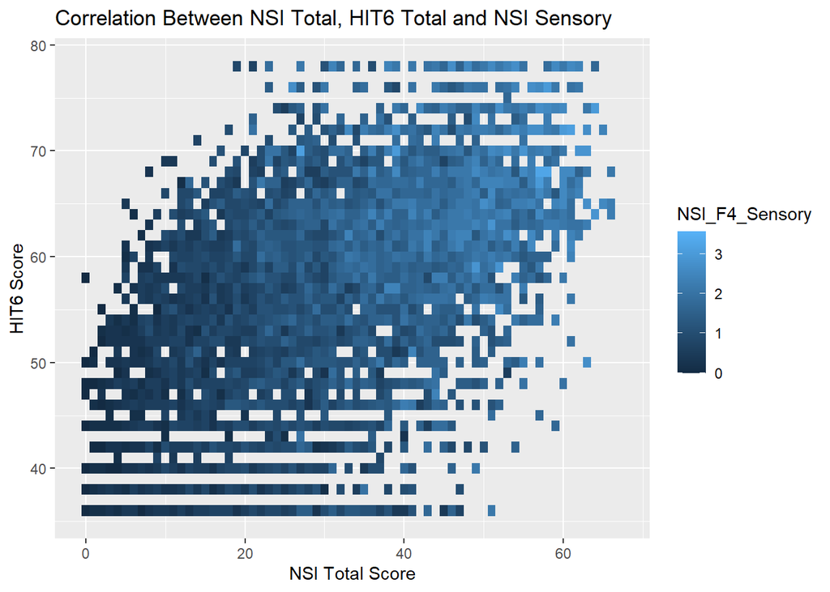

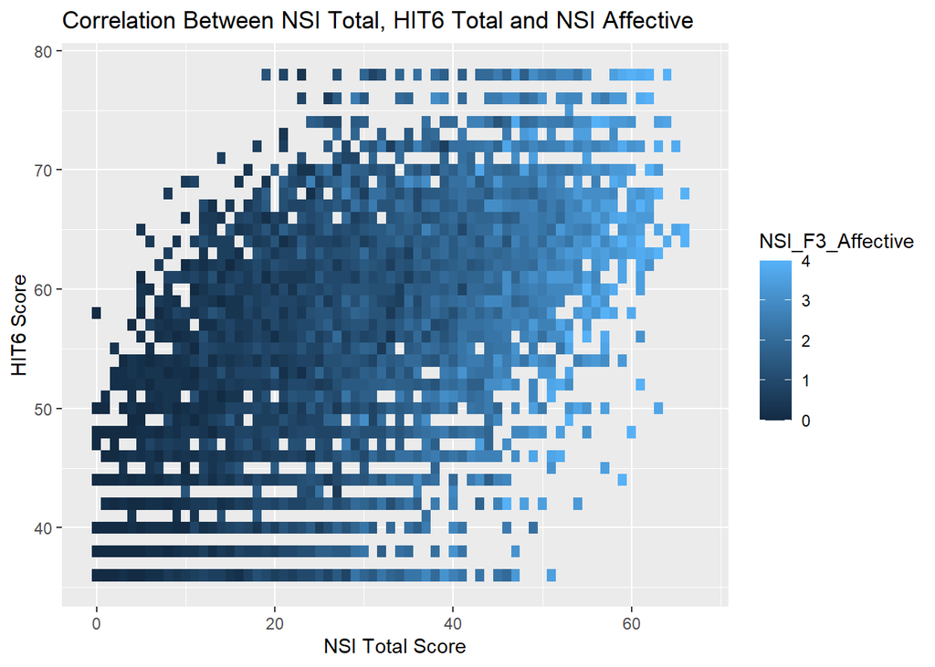

NSI Total Score, HIT6, And NSI COGNATIVE

|  | NSI Total Score |  |  |
| --- | --- | --- | --- |
| Predictors | Estimates | CI | p |
| (Intercept) | -7.33 | -8.80 – -5.86 | **<0.001** |
| HIT6_Score | 0.32 | 0.29 – 0.35 | **<0.001** |
| NSI_F2_Cognative | 4.83 | 4.05 – 5.61 | **<0.001** |
| HIT6_Score * NSI_F2_Cognative | 0.12 | 0.10 – 0.13 | **<0.001** |
| Observations | 8332 |  |  |
| R<sup>2</sup> / R<sup>2</sup> adjusted | 0.842 / 0.842 |  |  |

### NSI and PHQ9

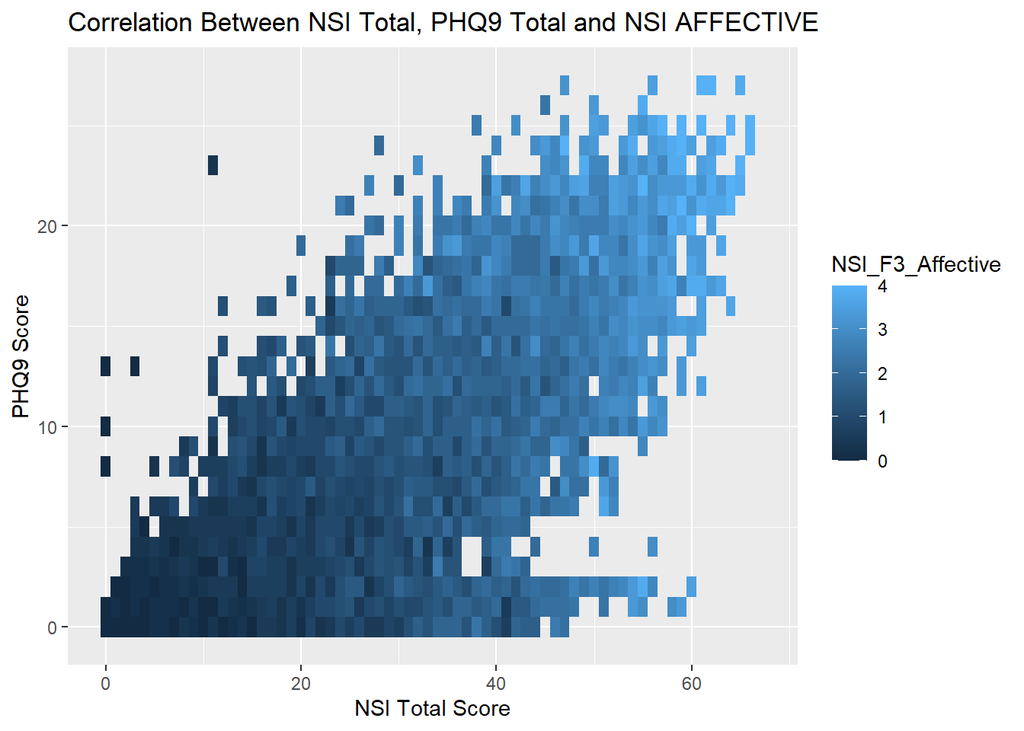

NSI Total Score, PHQ9 and NSI AFFECTIVE

|  | NSI Total Score |  |  |
| --- | --- | --- | --- |
| Predictors | Estimates | CI | p |
| (Intercept) | 4.91 | 4.46 – 5.36 | **<0.001** |
| PHQ9_Score | 0.09 | 0.02 – 0.16 | **0.009** |
| NSI_F3_Affective | 13.54 | 13.22 – 13.85 | **<0.001** |
| PHQ9_Score * NSI_F3_Affective | 0.07 | 0.05 – 0.10 | **<0.001** |
| Observations | 7628 |  |  |
| R<sup>2</sup> / R<sup>2</sup> adjusted | 0.831 / 0.830 |  |  |

### NSI and PHQ8

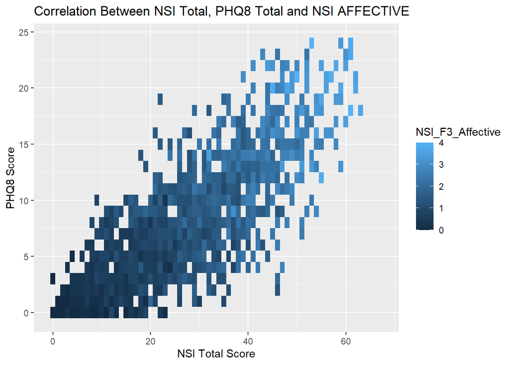

NSI Total Score, PHQ8 and NSI AFFECTIVE

|  | NSI Total Score |  |  |
| --- | --- | --- | --- |
| Predictors | Estimates | CI | p |
| (Intercept) | 4.30 | 3.22 – 5.39 | **<0.001** |
| phq8_tot_score | 0.49 | 0.32 – 0.67 | **<0.001** |
| NSI_F3_Affective | 13.17 | 12.28 – 14.06 | **<0.001** |
| phq8_tot_score * NSI_F3_Affective | 0.00 | -0.05 – 0.06 | 0.882 |
| Observations | 1337 |  |  |
| R<sup>2</sup> / R<sup>2</sup> adjusted | 0.839 / 0.839 |  |  |

### NSI and GAD7

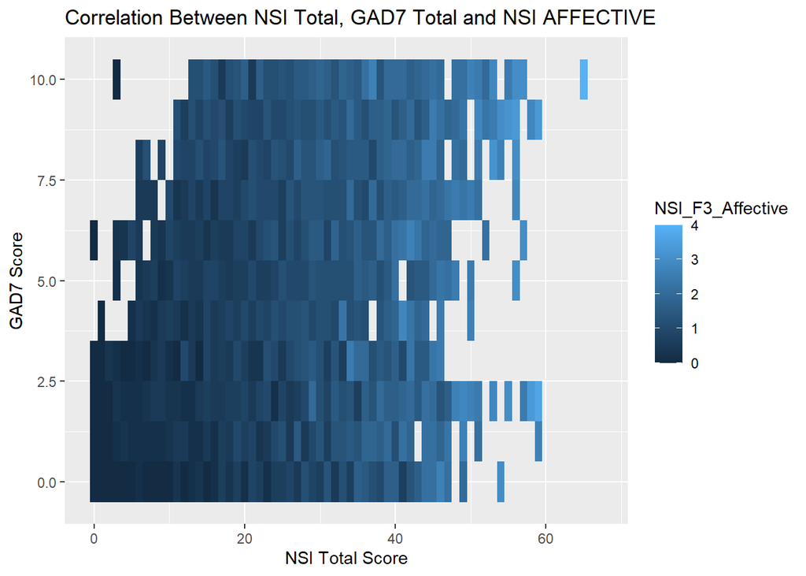

NSI Total Score, GAD7, and NSI Affective

|  | NSI Total Score |  |  |
| --- | --- | --- | --- |
| Predictors | Estimates | CI | p |
| (Intercept) | 4.19 | 3.76 – 4.62 | **<0.001** |
| GAD_Score | 0.06 | -0.07 – 0.19 | 0.353 |
| NSI_F3_Affective | 15.18 | 14.81 – 15.55 | **<0.001** |
| GAD_Score * NSI_F3_Affective | -0.06 | -0.14 – 0.01 | 0.110 |
| Observations | 5302 |  |  |
| R<sup>2</sup> / R<sup>2</sup> adjusted | 0.749 / 0.749 |  |  |

### NSI and ISI

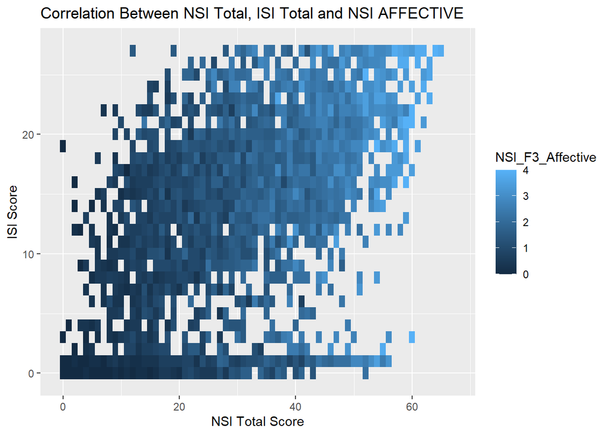

NSI Total Score, ISI and NSI AFFECTIVE

|  | NSI Total Score |  |  |
| --- | --- | --- | --- |
| Predictors | Estimates | CI | p |
| (Intercept) | 4.82 | 4.26 – 5.37 | **<0.001** |
| ISI_Score | -0.07 | -0.12 – -0.01 | **0.016** |
| NSI_F3_Affective | 14.91 | 14.52 – 15.30 | **<0.001** |
| ISI_Score * NSI_F3_Affective | 0.04 | 0.01 – 0.06 | **0.002** |
| Observations | 4359 |  |  |
| R<sup>2</sup> / R<sup>2</sup> adjusted | 0.830 / 0.830 |  |  |

### NSI and PCL5

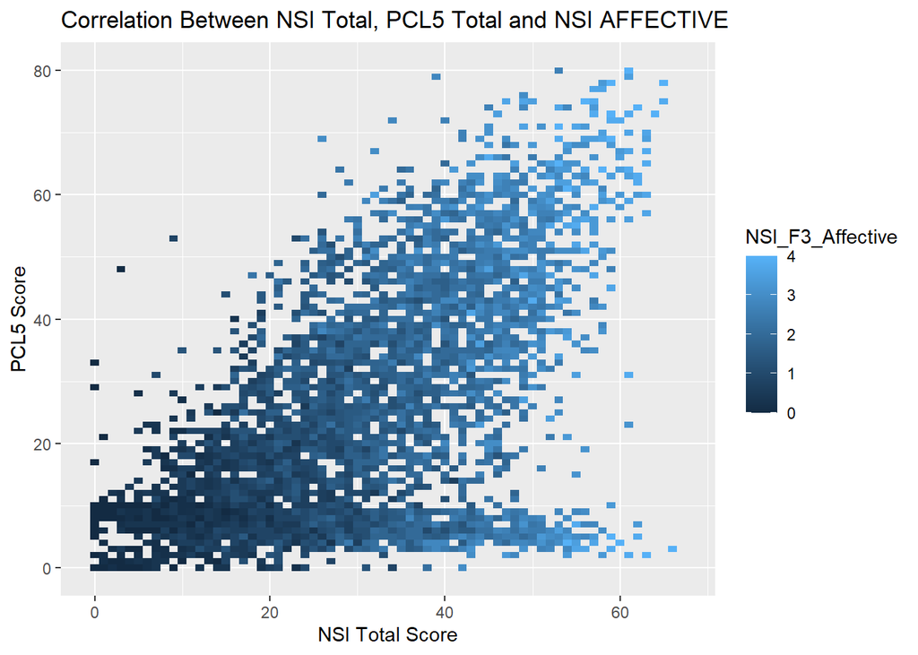

NSI Total Score, PCL5 and NSI AFFECTIVE

|  | NSI Total Score |  |  |
| --- | --- | --- | --- |
| Predictors | Estimates | CI | p |
| (Intercept) | 4.62 | 4.03 – 5.20 | **<0.001** |
| pcl520_tot_score | 0.06 | 0.03 – 0.09 | **<0.001** |
| NSI_F3_Affective | 14.25 | 13.93 – 14.56 | **<0.001** |
| pcl520_tot_score * NSI_F3_Affective | 0.01 | -0.00 – 0.02 | 0.105 |
| Observations | 5168 |  |  |
| R<sup>2</sup> / R<sup>2</sup> adjusted | 0.833 / 0.833 |  |  |

### NSI and PCLM

[figure not shown]

NSI Total Score, PCLM and NSI AFFECTIVE

|  | NSI Total Score |  |  |
| --- | --- | --- | --- |
| Predictors | Estimates | CI | p |
| (Intercept) | 1.79 | 1.05 – 2.52 | **<0.001** |
| pclm_tot_score | 0.14 | 0.12 – 0.17 | **<0.001** |
| NSI_F3_Affective | 12.15 | 11.74 – 12.56 | **<0.001** |
| pclm_tot_score * NSI_F3_Affective | 0.02 | 0.01 – 0.03 | **<0.001** |
| Observations | 9139 |  |  |
| R<sup>2</sup> / R<sup>2</sup> adjusted | 0.844 / 0.844 |  |  |

### NSI and ABC

[figure not shown]

NSI Total Score, ABC, and NSI VESTIBULAR

|  | NSI Total Score |  |  |
| --- | --- | --- | --- |
| Predictors | Estimates | CI | p |
| (Intercept) | 22.33 | 18.12 – 26.53 | **<0.001** |
| abc_tot_score | -0.04 | -0.08 – 0.01 | 0.105 |
| NSI_F1_Vestibular | 14.45 | 12.30 – 16.60 | **<0.001** |
| abc_tot_score * NSI_F1_Vestibular | 0.00 | -0.03 – 0.03 | 0.973 |
| Observations | 1582 |  |  |
| R<sup>2</sup> / R<sup>2</sup> adjusted | 0.539 / 0.538 |  |  |

### NSI and DHI

[figure not shown]

NSI Total Score, DHI and NSI VESTIBULAR

|  | NSI Total Score |  |  |
| --- | --- | --- | --- |
| Predictors | Estimates | CI | p |
| (Intercept) | 17.41 | 16.71 – 18.11 | **<0.001** |
| dhi_tot_score | 0.19 | 0.16 – 0.22 | **<0.001** |
| NSI_F1_Vestibular | 11.58 | 10.85 – 12.31 | **<0.001** |
| dhi_tot_score * NSI_F1_Vestibular | 0.00 | -0.01 – 0.02 | 0.531 |
| Observations | 3959 |  |  |
| R<sup>2</sup> / R<sup>2</sup> adjusted | 0.617 / 0.617 |  |  |

### NSI and EPWORTH

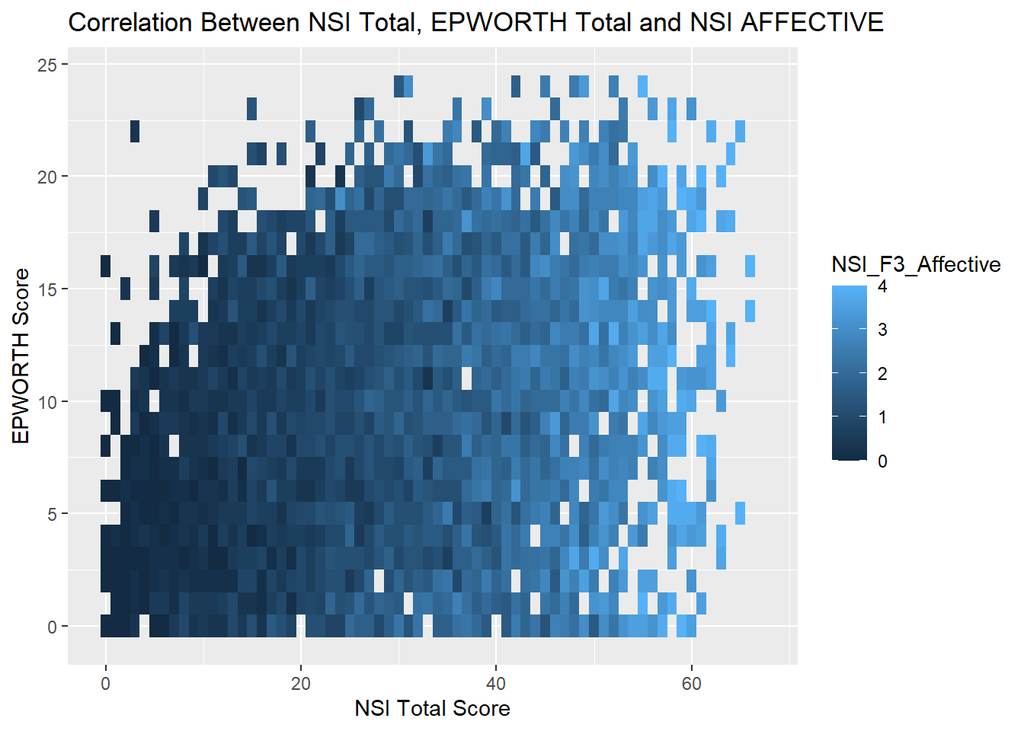

NSI Total Score, Epworth and NSI AFFECTIVE

|  | NSI Total Score |  |  |
| --- | --- | --- | --- |
| Predictors | Estimates | CI | p |
| (Intercept) | 2.41 | 1.69 – 3.14 | **<0.001** |
| epworth_tot_score | 0.15 | 0.07 – 0.23 | **<0.001** |
| NSI_F3_Affective | 15.27 | 14.91 – 15.63 | **<0.001** |
| epworth_tot_score * NSI_F3_Affective | 0.01 | -0.02 – 0.05 | 0.424 |
| Observations | 5751 |  |  |
| R<sup>2</sup> / R<sup>2</sup> adjusted | 0.830 / 0.830 |  |  |

### NSI and QOL

[figure not shown]

NSI Total Score, WHOQOL and NSI AFFECTIVE

|  | NSI Total Score |  |  |
| --- | --- | --- | --- |
| Predictors | Estimates | CI | p |
| (Intercept) | 8.95 | 5.33 – 12.58 | **<0.001** |
| qol_total | -0.06 | -0.12 – -0.00 | **0.036** |
| NSI_F3_Affective | 15.90 | 14.57 – 17.24 | **<0.001** |
| qol_total * NSI_F3_Affective | -0.03 | -0.05 – -0.01 | **0.013** |
| Observations | 2745 |  |  |
| R<sup>2</sup> / R<sup>2</sup> adjusted | 0.825 / 0.824 |  |  |

### NSI and AUDIT

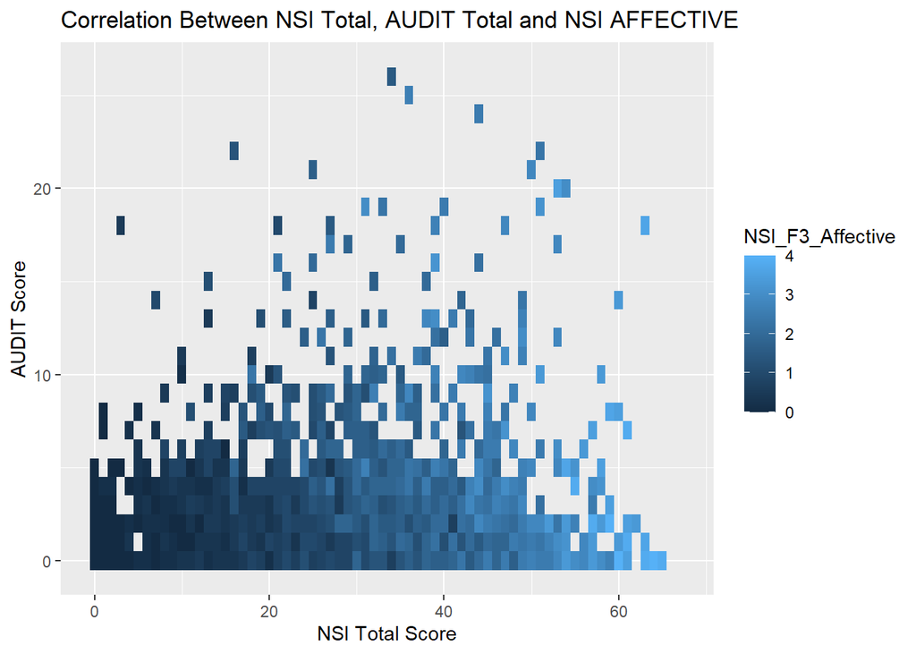

NSI Total Score, AUDIT and NSI AFFECTIVE

|  | NSI Total Score |  |  |
| --- | --- | --- | --- |
| Predictors | Estimates | CI | p |
| (Intercept) | 4.80 | 4.10 – 5.51 | **<0.001** |
| AUDIT_Score | -0.25 | -0.46 – -0.03 | **0.024** |
| NSI_F3_Affective | 15.46 | 15.12 – 15.81 | **<0.001** |
| AUDIT_Score * NSI_F3_Affective | 0.05 | -0.04 – 0.14 | 0.272 |
| Observations | 2465 |  |  |
| R<sup>2</sup> / R<sup>2</sup> adjusted | 0.832 / 0.832 |  |  |

### Heat Map

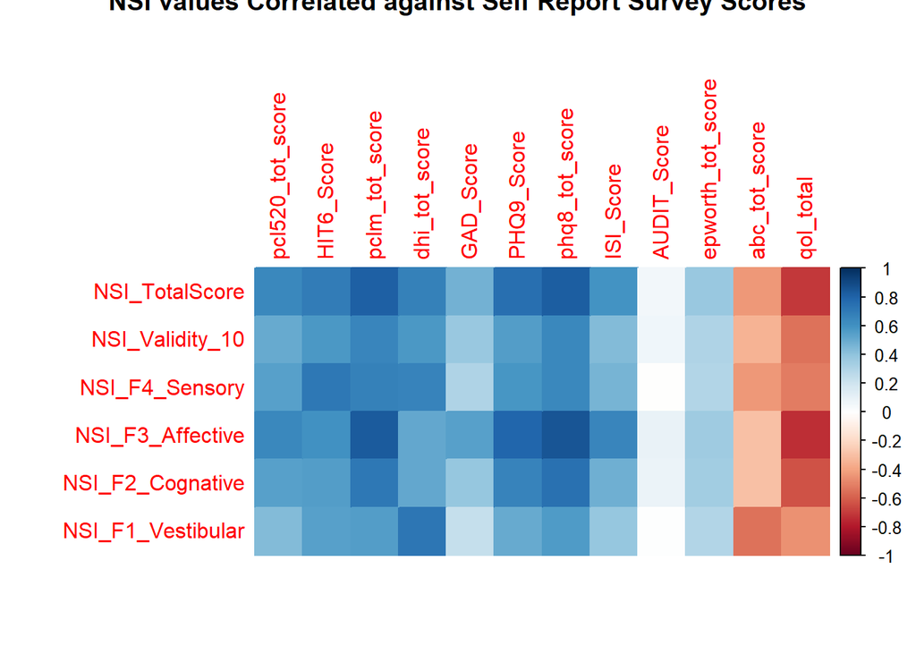

## Demographics

### Plot

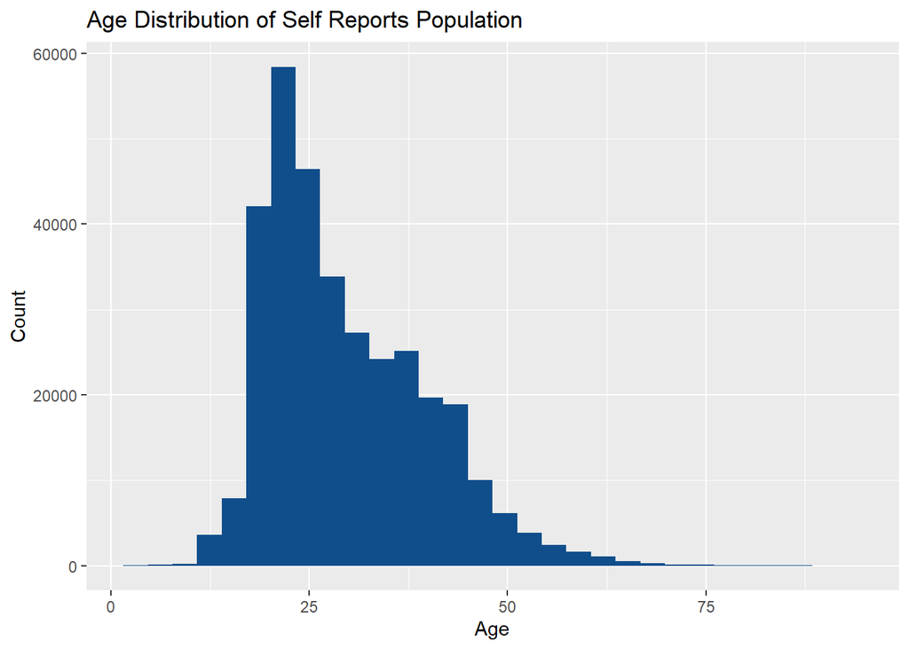

### Service Branch

Sponsor Service Counts

| SponServAgg | count |
| --- | --- |
| Army | 89.87% (300038) |
| Air Force | 3.80% (12679) |
| Navy | 2.89% (9635) |
| Marine | 1.62% (5394) |
| Z | 0.73% (2432) |
| V | 0.71% (2354) |
| Coast Guard | 0.28% (922) |
| Unknown | 0.12% (406) |
| Total | 100.00% (333860) |

### Gender

Gender Counts

| Gender | count |
| --- | --- |
| M | 67.70% (226039) |
| F | 32.29% (107819) |
|  | 0.00% (2) |
| Total | 100.00% (333860) |

### Race

Race Counts

| Race | count |
| --- | --- |
| Caucasian | 43.01% (143587) |
| Other | 34.25% (114351) |
| African American | 18.94% (63238) |
| Asian | 3.35% (11179) |
| Native American/Pacific Islander | 0.45% (1505) |
| Total | 100.00% (333860) |

### Marital Status

Marital Status Counts

| Marital_Stat | count |
| --- | --- |
| Married | 39.53% (131976) |
| Other | 31.98% (106757) |
| Single | 18.81% (62801) |
| Unkown | 6.31% (21051) |
| Divorced | 3.04% (10135) |
| Legally Seperated | 0.23% (760) |
| Widow | 0.10% (320) |
| Anulled | 0.01% (41) |
| Interlocutory | 0.01% (19) |
| Total | 100.00% (333860) |

### BenCat

BENCAT Counts

| BenCatCom | count |
| --- | --- |
| 4 | 81.45% (271914) |
| 1 | 11.52% (38466) |
| 3 | 4.61% (15396) |
| 2 | 2.41% (8041) |
| NA | 0.01% (43) |
| Total | 100.00% (333860) |